# Emails of Hilliary Clinton

Cheuk Kin POON

May 24, 2016

# Introduction

In this project, the emails of Hillary Clinton will be analysed to investigate the content of her emails and her email connections. In the first part, we will first look at different contacts of her and her network as the secretary of state. After that, a simple topic modelling analysis with hierarchical clustering techniques will be done on the contents of her emails.

# Contacts of Hillary

In this section, the network and contacts of Hillary will be analysed and visualised to answer the following questions:

1. Who are her regular contacts?
2. Who has sent her the most number of emails?
3. Who she usually sends her emails to?
4. Who are her main source of information and middleman?
5. Are the communications mutual?(Does Hillary send emails as much as she receives?)

## Top senders and receivers

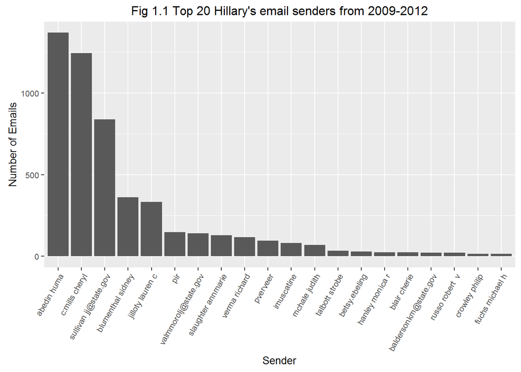

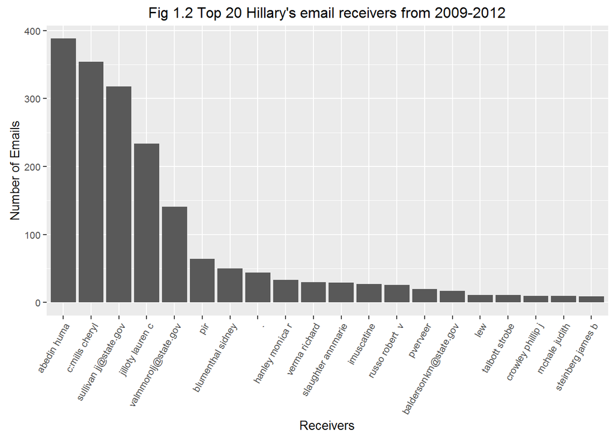

## Interactions

From Fig 1.1 and 1.2 above, we can see that Abedin Huma was her most regular contact and then C:mills Cheryl, Jacob Sullivan and Jilloty Lauren c. Also, by the similarity of order and members of the lists, we can see that the communication was often mutual. To further understand her relationship with other people, we can look at the ratio between her receiving emails from a person and she sending emails to that person. It is assumed that someone who worked together with Hillary should have more mutual communication with her and therefore the ratio should be closer to 1. On the other hand, some email contacts may just be information providers.

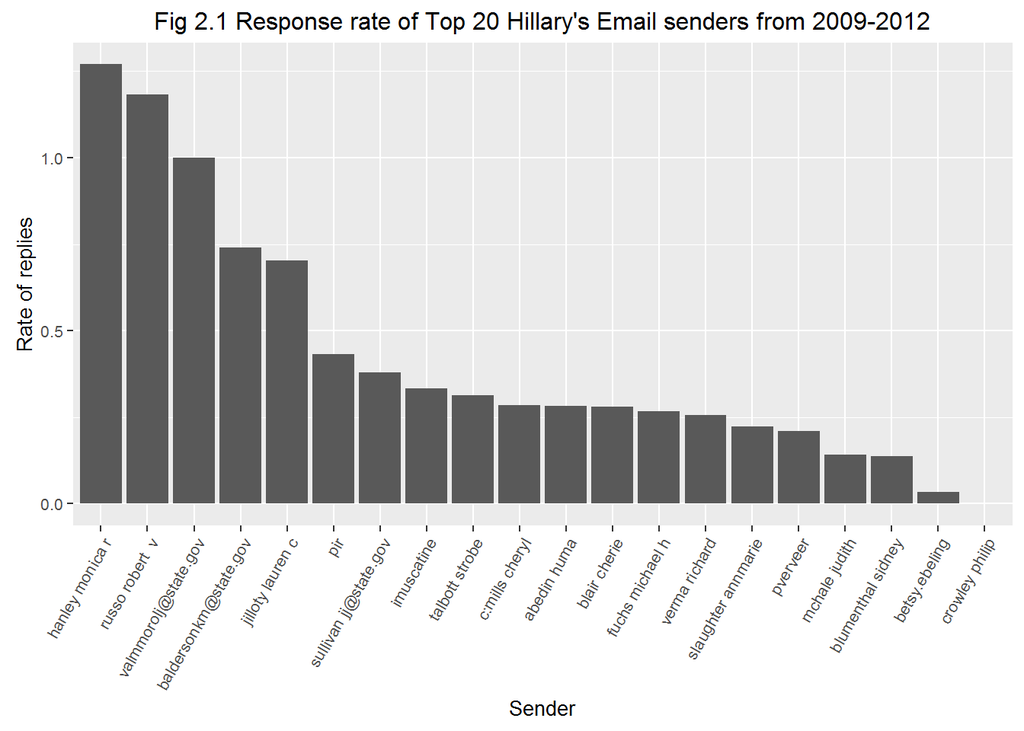

From Fig 2.1, it is interesting to see Hilliary was not equally responsive to all email ID. i.e. some email contacts were more like an information provider then a co-worker of Hilliary. Notice that there are “Crowley Philip” and “Crowley Phillip j”. They probably belong to the same person but they were different email accounts. Interestingly, Hillary did interact with “Crowley Philip j” which was a government official domain while she never replied any emails from “Crowley Philip” which is suspected to be a non-government email account.

Here are some findings from the internet who were these people and their relationships with Hillary.

Monica R. Hanley - Hillary’s Transition Personal Office Director

http://dailycaller.com/2016/02/19/longtime-clinton-aide-also-used-personal-email-address-at-state-department/

Russo Robert - Hillary’s Special Assistant to the Secretary of State

https://www.linkedin.com/in/robert-russo-07b56015 http://www.nationalreview.com/article/427792/new-e-mails-released-highlight-clintons-post-concussion-confusion-brendan-bordelon

Lona Valmoro - Hillary’s Special Assistant to the Secretary of State

https://semesterinwashington.gwu.edu/lona-valmoro

Crowley Philip - United States Assistant Secretary of State for Public Affairs

https://en.wikipedia.org/wiki/Philip_J._Crowley

http://money.cnn.com/2015/10/01/media/hillary-clinton-60-minutes-planted-questions/

Betsy Ebeling - Oldest friend of Hillary

http://www.politico.com/story/2016/01/hillary-clinton-iowa-friend-ebeling-218491

Sidney Blumenthal - Reporter

https://en.wikipedia.org/wiki/Sidney_Blumenthal

From the research above, Hillary was most responsive to her aide and emails related to her job while much less responsive to non-official emails. With the analysis of how responsive Hilliary to different contacts, one may further found out her colleagues and people who work directly for her.

## Network Investigation

To further define the layers of her email network, the scatter plots below shows the scaled number of emails send/received by Hillary to/from different persons.

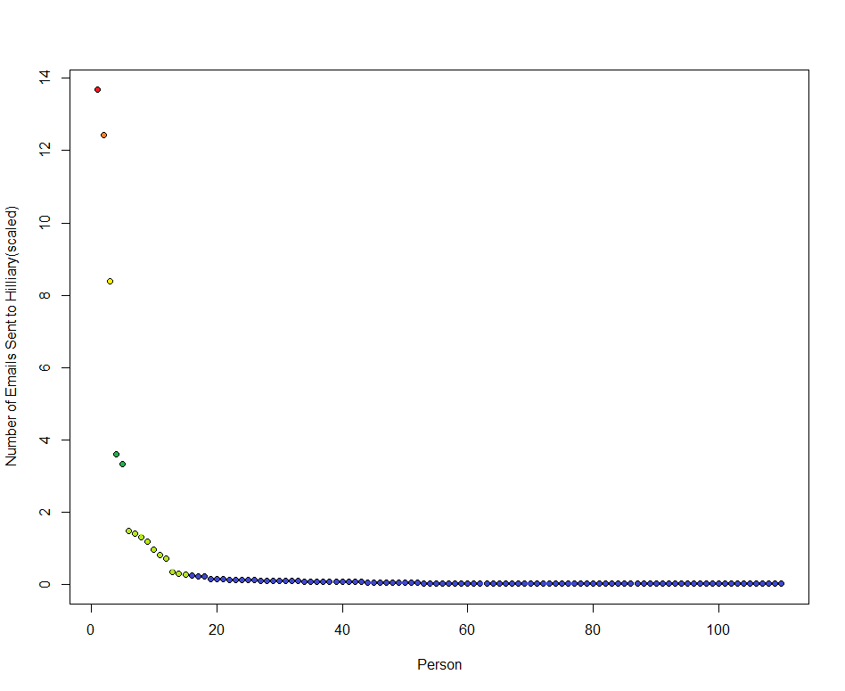

Fig 3.1

In fig 3.1, each dots above represent an email-sender of Hillary. The x-axis shows the nth top email-sender of Hillary and the y-axis shows the scales number of emails sent.

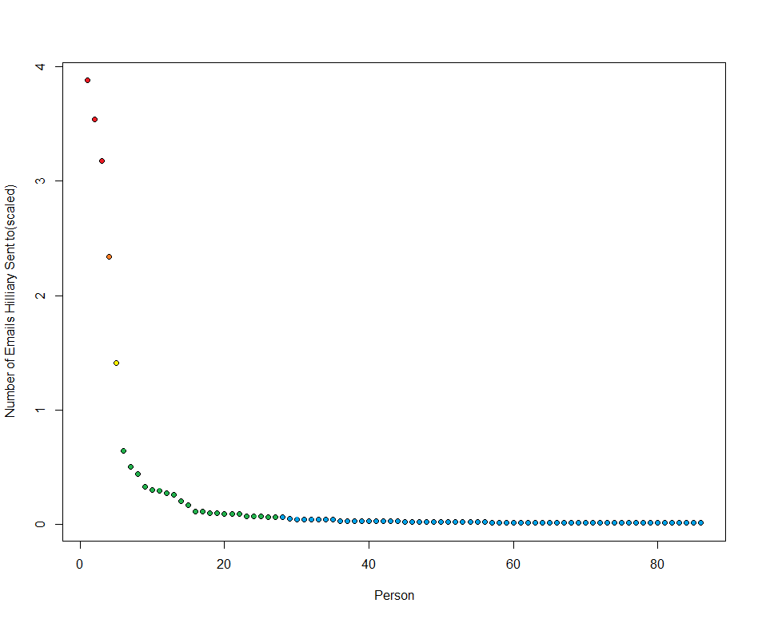

Fig 3.2

in fig 3.2, each dots above represent a receiver of Hillary. The x-axis shows the nth top receiver of Hillary and the y-axis shows the scales number of emails received.

After seeing all discrete analysis of her network, her email network is visualised below.

#### The Network of Emails received by Hillary

Colour: The black nodes in the middle is Hillary herself. The red nodes are those who sent her emails.The brighter in red is the node, the more emails he/she sent to Hillary. The other end of the spectrum is in blue colour. The brighter in blue is the node, the less email they sent to Hillary.

The size of nodes:The size of nodes representing the indegree centrality of the node(person/email account).The larger the size, more the information sent to the node.

Link: The links represents email contacts between the nodes. The thicker the link, more emails were sent between the nodes.

[interactive chart not shown]

#### The Network of Emails sent by Hillary

Colour: The black nodes in the middle is Hillary herself. The red nodes are those who receive her emails.The brighter in red is the node, the more emails he/she received from Hillary. The other end of the spectrum is in blue colour. The brighter in blue is the node, the less email they received from Hillary.

The size of nodes:The size of nodes representing the indegree centrality of the node(person/email account).The larger the size, more the information sent to the node.

Link: The links represents email contacts between the nodes. The thicker the link, more emails were sent between the nodes.

[interactive chart not shown]

From the network and bar charts above, we can see that Abedin Huma and Cmill Cheryl are both the main contacts and bridges of Hillary to many others. The unknown people/account “.” is also very interesting as it appears to be a bridge of many other contacts which are media contacts such as LA-times, new york times, Finca International, foreign affair magazines etc. Also, it receives only emails from Hillary but it never sends an email to Hillary. So it might be in charge of the release of news from Hillary to the public media.

Another interesting remark is that the isolated bits surrounding the main networks. They probably come from CCs of emails and they give us some hints about what other external networks near Hillary would be.

# Contents of Emails

After visualising her contacts, the topics and contents of her emails should be investigated. For simplicity sake, we only look into the emails of the year 2012.

## Methodology on Clustering

To investigate the content, the topics within the email must first be investigated. Hierarchical clustering is employed here as an unsupervised machine learning method to find out the topics in 2012. To do that, nouns and useless stopwords were first removed (stopwords(“English”) and stopwords(“SMART”)) and then the word sets were further filtered. Only words with at least 5 times and appearance in at least 3 documents will be taken into account. Each email was then made into a matrix with a list of words.

### Evaluation on Distance Metrics

It is then ready for clustering. The clustering function used here is called hclust from the package “quanteda”. Note that as the raw text of the emails are rather long, the number of dimensions is, therefore, big and the “curse of dimensions” may appear. To deal with the problem, we should consider using PCA or consider using distance metrics which are less affected by the number of dimensions. From the package, a build-in package dist() is provided to calculate the distance between objects with distance metrics Euclidean(2-norm), maximum (sup-norm), Manhattan distance(1-norm), Minkowski(p-norm), Canberra and asymmetric binary distance. Evaluations on these metrics are shown below.

#### Euclidean(2-norm):

It is a good distance metric in low dimensional space. In our case, the dimension may be too much and therefore points may be all far away from each other without significant difference. Furthermore, the lengths of the vectors have also a significant effect on the distance metric and therefore a long email will not be considered to be similar to a short email even the longer email contain a lot of words from the short one. Also, the metric could be largely dominated by frequent words which may not be the keywords for the topic.

#### Maximum(sup-norm):

The one-norm, similar to the 2-norm, facing the similar problem but it is even more cursed by dimensionality and it measures the most difference among the p-norms. However, it is better in a sense that it is less dominated by frequent words when compared with 2-norm.

#### Manhattan(1-norm):

The one-norm, similar to the 2-norm, facing similar problem but it is even more cursed by dimensionality and it measures the most difference among the p-norms. However it is better in a sense that it is less dominated by frequent words when compared with 2-norm.

#### Minkowski(p-norm):

This is a generalisation of the 1 & 2 norm. As p increases, the norm gets more focused on the biggest difference between the components of the two vectors. As p tends to infinity, its value tends to the value of sup-norm.

#### Canberra

It measures sum(|x_i - y_i| / |x_i + y_i|) as the distance between vector x and y. It is a better distance metric than the p-norms as it takes care of the weighting of those frequent words by dividing each entry by |x_i + y_i|.

#### Binary(asymmetric binary)

It is constructed by counting distinct number of words contained in both emails and then divided by the total number of distinct words within the two. This method therefore takes care of the potential problem of frequent non-keywords. However, the appearence of unimportant words may affect the measure much more than the 1 and 2 norms. Ideally, removing the stopwords should take care of this problem.

According to the evaluations above, all clustering has their own pros and cons and according to the different situation, such as how clean the data is, a different metric may give a different result. For example, if we have a large variation in the length of emails, euclidean distance or generally the p-norms may give very bad results as it cannot group short emails with long emails even they share similar subjects. On the other hand, metrics such as the binary metric completely ignore the frequencies of words by assigning all the words with the same weight. If there were a lot of distinct unimportant words(non-informative and non-frequent words), our result will be badly affected under these metrics. Under the assumption that our stopwords are sufficient, Canberra and Binary could be a better option. In the following analysis, Euclidean will be tested with other appropriate metric settings as a comparison with Binary and Canberra metrics and also an indicator of the performance of general p-norm.

#### Discussion - similarity metrics and further analysis:

Despite our intuition, in some case, “similarity” does not neccessarily to be mutual. For instance, a longer email may contain all the keywords of another shorter email but the shorter email may only covers a rather small proportion of keywords of the longer email. In this case, the short email is “similar” to the long email as the long email contains most of its content but the long one is NOT “similar” to the shorter email as the shorter one contains only a small part of its content. In this case, traditional clustering methods are no longer a good model to describe such structure as distance metrics are mutual(i.e. d(A,B)=d(B,A)) while “similarity” is not. In fact, to more accurately describe the contents of a set of documents, a network structure with directed links could be a much more accurate model on describing the relationship between each documents. By evaluating features of document A contained in document B, the weight of the directed link from A to B can be evaluated as,

$$W(A,B)=\frac{|A \cap B |}{|A|}$$
.

By normalising the weights of links or setting threshold, a network structure showing the relationship between documents could be revealed. Larger documents with more contents will have higher in-degree centrality, surrounded by a number of smaller documents with parts of its content and therefore the hierachical structure of main topics and sub-topics can be observed. Many different kind of network analysis could be done to investigate the similarity between documents. Analysis such as maximum cost spanning tree and betweeness centrality will help to understand transitions between topics. Community detection algorithm such as dispersion evalution can help regconising major topics and contents.

For a symetric similarity metric like what is used in this report, if we would like to have shorter emails to cluster with longer emails if the longer email contains its keywords, one possible solution is to adjust the length of each emails by multiplying their respective vectors by a variable that is inversely proportional to their length such that the effect of the lengths of the emails would be normalised.

### Evaluation on Link Methods

Without looking into the details of the quality of the data, the best method to find out the best metric is to do a testing on each metric. To decide which metric to use, we need to first visualise the effect of each method. As our aim is to find out emails with a similar topic, we hope to find clusters containing different sets of words. For the linking methods, the hierarchical clustering functions provide different linkage types such as single link, complete link, average link, centroid and Ward’s minimum variance method. Here are the evaluation of each linkage methods.

#### Single link method

Single link method measures distance between clusters as the minimum distance between their members. This will not a good linkage method in our case as single link methods tend to form a big trunk of clusters. Furthermore, there could be huge variation within a cluster, result in clustering emails of different topics within a single cluster.

#### Complete link method

A potential candidate for our clustering here. The complete link method evaluates the distance between clusters as the maximum distance between their members. As a result, it limits the size of the domain of clusters as well as the variation within clusters which is exactly what we want in our topic clustering.

#### Ward’s minimum variance method

This method is to minimise the variance within clusters after each merging by optimising a special version of William-Lance formula. It can also be taken as a special case of the Lance-Williams formula. This method actually has a similar effect as the complete link but with more direct and clear objective. So this should be the ideal link method for our clusters.

### Evaluation on number of clusters

For clustering, we would always want to know what is the optimal level of clustering and there is always a trade-off between the number of clusters and the fitness of the model. Consider clustering a process of summarising a complex structure. Although our goal is to summarise the structure to make things easy to understand, the more we summarise a structure, the more information is lost. In our package, two different methods are provided to determine the level of clustering. One by the number of desired clusters k and the other one is by height.

#### Optimal Number of Clusters k

To test for the best result, apply the “ward.D2” link for Euclidean, Canberra and Binary distance metrics. For the optimal number of clusters, methods such as the elbow method on sum square error, maximum mean silhouette or information criterion are good methods to determine the right number of clusters. Most of these methods are trying to measure and make a trade-off between the fitness of clusters and the complexity(number of clusters) in the model.

#### Optimal Height h

Instead of looking into the best value of k, another alternative is to compare the height of each link in the dendrogram. In the dendrograms, the height of each link represents the link distance between the two clusters. So the height difference between links indicates the inconsistency of the link. Therefore an optimal level to cluster would be the level when the height started to increase exponentially.

Here an optimal h will be used as it requires no further packages, functions or programming.

## Visualise and Compare the Quality of Clusters

### Euclidean distance

First, let us see the results from the euclidean distance.

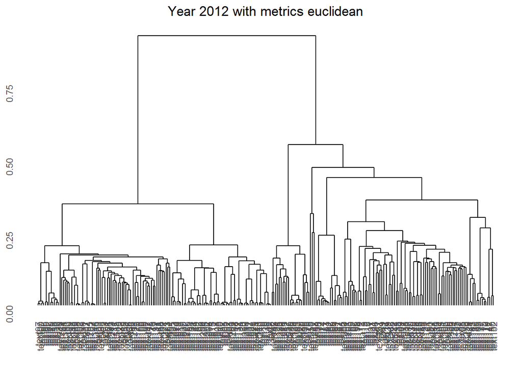

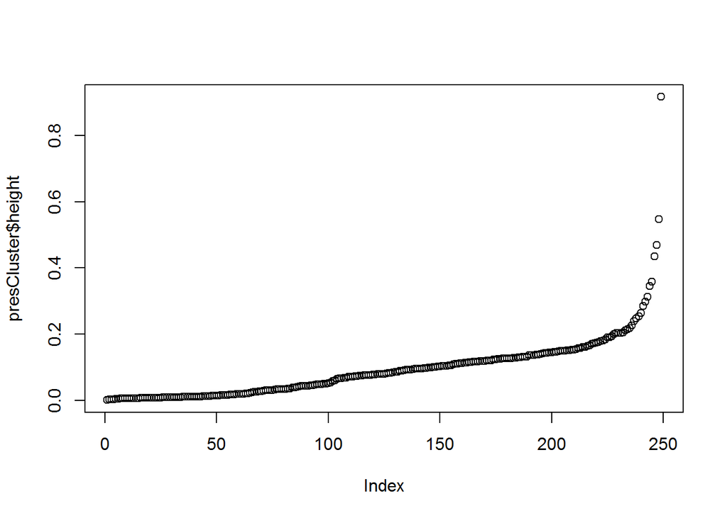

Here, the “Elbow”" is located around the level 0.2 and therefore h=0.2 is used for clustering.

#### The number of cuts:

```
## [1] "number of cuts: 23"
```

```
## cuts
##  3  4 16  2  1  9 11  7  5 10
## 61 28 27 24 18 12 11 10  8  8
```

#### Members of the 1st largest cluster.

```
##   text5   text6  text23  text25  text28  text30  text31  text34  text35
##       3       3       3       3       3       3       3       3       3
##  text47  text49  text50  text51  text59  text63  text64  text73  text88
##       3       3       3       3       3       3       3       3       3
##  text93  text98  text99 text102 text103 text104 text107 text109 text111
##       3       3       3       3       3       3       3       3       3
## text115 text116 text118 text119 text120 text122 text123 text127 text133
##       3       3       3       3       3       3       3       3       3
## text137 text141 text153 text154 text157 text159 text160 text164 text165
##       3       3       3       3       3       3       3       3       3
## text168 text178 text183 text184 text188 text189 text190 text193 text194
##       3       3       3       3       3       3       3       3       3
## text205 text207 text211 text218 text221 text243 text249
##       3       3       3       3       3       3       3
```

#### Members of the 2nd largest cluster.

```
##   text7   text8  text16  text18  text19  text20  text41  text52  text53
##       4       4       4       4       4       4       4       4       4
##  text55  text57  text58 text108 text114 text129 text130 text131 text132
##       4       4       4       4       4       4       4       4       4
## text140 text191 text209 text227 text228 text229 text230 text231 text232
##       4       4       4       4       4       4       4       4       4
## text240
##       4
```

#### Members of the 3rd largest cluster.

```
## text144 text149 text151 text155 text158 text162 text163 text166 text176
##      16      16      16      16      16      16      16      16      16
## text202 text204 text206 text208 text210 text212 text213 text214 text215
##      16      16      16      16      16      16      16      16      16
## text216 text217 text219 text220 text222 text223 text224 text225 text226
##      16      16      16      16      16      16      16      16      16
```

#### Members of the 4th largest cluster.

```
##   text3  text27  text56  text61  text90  text94  text95 text101 text105
##       2       2       2       2       2       2       2       2       2
## text106 text110 text121 text125 text135 text138 text161 text169 text173
##       2       2       2       2       2       2       2       2       2
## text180 text182 text187 text192 text234 text239
##       2       2       2       2       2       2
```

#### Members of the 5th largest cluster.

```
##   text1   text2   text4   text9  text11  text12  text13  text14  text15
##       1       1       1       1       1       1       1       1       1
##  text17  text21  text22  text24  text26 text139 text171 text244 text245
##       1       1       1       1       1       1       1       1       1
```

#### Keywords for 1st largest cluster.

| word1 | word2 | word3 | count | G2 |
| --- | --- | --- | --- | --- |
| state | dept |  | 469 | 4331.4518 |
| state | case |  | 469 | 4088.4984 |
| unclassified | u.s |  | 468 | 4667.8006 |
| foia | waiver |  | 464 | 5791.1544 |
| house | select |  | 464 | 5417.1029 |
| sensitive | information |  | 464 | 5338.8775 |
| benghazi | comm |  | 464 | 5021.4426 |
| select | benghazi |  | 464 | 4756.9773 |
| 2015 | state |  | 454 | 4019.1989 |
| secretary | clinton |  | 226 | 2500.6275 |
| united | states |  | 175 | 2309.6470 |
| state | department |  | 99 | 774.3839 |
| chris | stevens |  | 53 | 632.2139 |
| foreign | minister |  | 40 | 419.2456 |
| middle | east |  | 38 | 616.7533 |
| susan | rice |  | 34 | 453.3653 |
| prime | minister |  | 33 | 467.9783 |
| ambassador | chris |  | 32 | 300.1645 |
| president | obama |  | 30 | 291.5937 |
| ansar | al |  | 28 | 378.8939 |

#### Keywords for 2nd largest cluster.

| word1 | word2 | word3 | count | G2 |
| --- | --- | --- | --- | --- |
| foia | waiver |  | 244 | 3035.5656 |
| house | select |  | 244 | 2932.1955 |
| benghazi | comm |  | 244 | 2800.7777 |
| select | benghazi |  | 244 | 2559.9466 |
| sensitive | information |  | 244 | 2419.7790 |
| state | dept |  | 244 | 2311.6226 |
| state | case |  | 238 | 2218.5469 |
| unclassified | u.s |  | 237 | 2434.3579 |
| 2015 | state |  | 232 | 2084.2666 |
| sensitive | source |  | 133 | 962.5834 |
| el | magariaf |  | 113 | 1053.6248 |
| prime | minister |  | 96 | 1190.4210 |
| source | comment |  | 81 | 936.5378 |
| western | intelligence |  | 68 | 626.8814 |
| libyan | national |  | 56 | 327.0581 |
| united | states |  | 54 | 730.4369 |
| security | services |  | 54 | 510.6278 |
| transitional | council |  | 50 | 685.2944 |
| national | transitional |  | 50 | 561.7645 |
| ansar | al |  | 48 | 496.9345 |

#### Keywords for 3rd largest cluster.

| word1 | word2 | word3 | count | G2 |
| --- | --- | --- | --- | --- |
| foia | waiver |  | 186 | 2394.5825 |
| house | select |  | 186 | 2355.7815 |
| benghazi | comm |  | 186 | 2132.7538 |
| select | benghazi |  | 186 | 2065.9738 |
| sensitive | information |  | 186 | 1965.3491 |
| state | dept |  | 186 | 1858.6681 |
| state | case |  | 184 | 1716.0400 |
| unclassified | u.s |  | 182 | 2219.3086 |
| 2015 | state |  | 180 | 1728.1054 |
| sensitive | source |  | 97 | 718.9634 |
| source | comment |  | 88 | 1021.4997 |
| national | transitional |  | 74 | 799.5520 |
| prime | minister |  | 71 | 766.7032 |
| transitional | council |  | 66 | 855.0052 |
| national | army |  | 63 | 537.7861 |
| libyan | national |  | 54 | 373.0755 |
| civil | war |  | 48 | 692.2084 |
| direct | access |  | 40 | 474.7334 |
| highest | levels |  | 37 | 574.6573 |
| european | governments |  | 37 | 480.7126 |

#### Keywords for 4thlargest cluster.

| word1 | word2 | word3 | count | G2 |
| --- | --- | --- | --- | --- |
| foia | waiver |  | 58 | 597.07764 |
| house | select |  | 58 | 597.07764 |
| sensitive | information |  | 58 | 552.01316 |
| benghazi | comm |  | 58 | 529.47717 |
| select | benghazi |  | 58 | 529.47717 |
| state | dept |  | 58 | 426.96203 |
| state | case |  | 58 | 416.86004 |
| unclassified | u.s |  | 57 | 536.55551 |
| 2015 | state |  | 57 | 401.53056 |
| original | message |  | 10 | 124.82874 |
| september | 16 |  | 8 | 76.02154 |
| september | 11 |  | 8 | 56.99159 |
| command | center |  | 6 | 89.07572 |
| ds | command |  | 6 | 71.87846 |
| cairo | condemnation |  | 5 | 76.05434 |
| visas | obtained |  | 5 | 67.67856 |
| cheryl | 0 |  | 4 | 27.12114 |
| maghreb | affairs |  | 3 | 44.20050 |
| main | islamist |  | 3 | 44.20050 |
| islamist | militia |  | 3 | 40.38142 |

#### Keywords for 5th largest cluster.

| word1 | word2 | word3 | count | G2 |
| --- | --- | --- | --- | --- |
| foia | waiver |  | 40 | 397.24391 |
| house | select |  | 40 | 397.24391 |
| sensitive | information |  | 40 | 397.24391 |
| unclassified | u.s |  | 40 | 397.24391 |
| benghazi | comm |  | 40 | 387.84135 |
| select | benghazi |  | 40 | 387.84135 |
| 2015 | state |  | 40 | 280.98573 |
| state | case |  | 40 | 280.98573 |
| state | dept |  | 40 | 280.98573 |
| september | 12 |  | 31 | 255.23438 |
| original | message |  | 7 | 94.02851 |
| september | 13 |  | 7 | 56.18137 |
| b6 | unclassified |  | 6 | 22.14919 |
| quick | summary |  | 5 | 70.53265 |
| potus | calls |  | 5 | 65.12592 |
| amb | stevens |  | 5 | 54.54373 |
| pis | print |  | 4 | 58.21315 |
| 4g | lte |  | 3 | 45.38737 |
| wireless | 4g |  | 3 | 45.38737 |
| chris | stevens |  | 3 | 28.08166 |

#### Intersections from the clusters

| intersection |
| --- |
| foia waiver |
| house select |
| sensitive information |
| unclassified u.s |
| benghazi comm |
| select benghazi |
| 2015 state |
| state case |
| state dept |
| original message |
| b6 unclassified |
| jacob 3 |
| 26 pm |
| 33 pm |

### Canberra distance

Also, see the results from the Canberra.

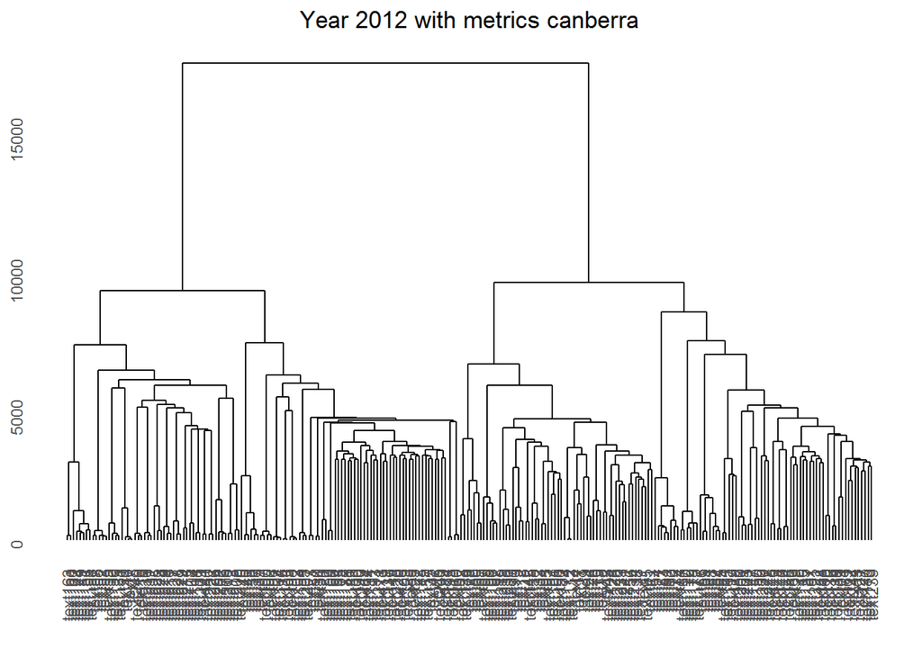

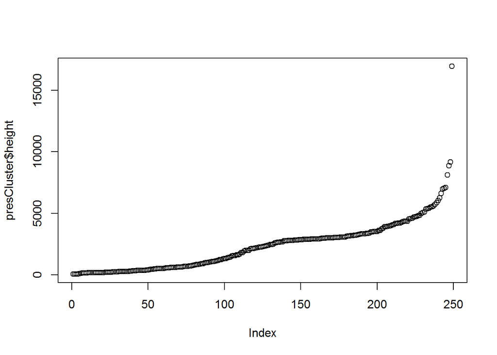

Here, the “Elbow”" is located around the level 5100 and therefore h=5100 is used for clustering.

#### The number of cuts:

```
## [1] "number of cuts: 19"
```

```
## cuts
##  1  3  2  5  7 10 15 17 11 12
## 48 47 42 25  8  8  8  8  7  7
```

#### Members of the 1st largest cluster.

```
##   text1   text2   text4   text9  text11  text12  text13  text15  text17
##       1       1       1       1       1       1       1       1       1
##  text21  text24  text26  text32  text33  text38  text42  text56  text61
##       1       1       1       1       1       1       1       1       1
##  text75  text76  text78  text90  text94  text95 text101 text105 text106
##       1       1       1       1       1       1       1       1       1
## text112 text113 text124 text126 text138 text145 text156 text171 text174
##       1       1       1       1       1       1       1       1       1
## text182 text192 text233 text234 text235 text236 text237 text238 text241
##       1       1       1       1       1       1       1       1       1
## text242 text245 text246
##       1       1       1
```

#### Members of the 2nd largest cluster.

```
##   text5   text6  text23  text25  text28  text30  text31  text35  text47
##       3       3       3       3       3       3       3       3       3
##  text49  text50  text51  text60  text62  text64  text73  text93  text99
##       3       3       3       3       3       3       3       3       3
## text109 text111 text115 text118 text119 text120 text123 text127 text133
##       3       3       3       3       3       3       3       3       3
## text137 text141 text153 text154 text157 text159 text160 text164 text178
##       3       3       3       3       3       3       3       3       3
## text183 text184 text188 text189 text190 text193 text211 text218 text220
##       3       3       3       3       3       3       3       3       3
## text243 text249
##       3       3
```

#### Members of the 3rd largest cluster.

```
##   text3  text10  text14  text22  text27  text44  text46  text48  text59
##       2       2       2       2       2       2       2       2       2
##  text63  text69  text71  text88 text110 text121 text122 text125 text135
##       2       2       2       2       2       2       2       2       2
## text136 text139 text142 text143 text146 text147 text148 text150 text152
##       2       2       2       2       2       2       2       2       2
## text161 text168 text169 text173 text180 text187 text200 text201 text203
##       2       2       2       2       2       2       2       2       2
## text221 text239 text244 text247 text248 text250
##       2       2       2       2       2       2
```

#### Members of the 4th largest cluster.

```
##  text18  text19  text41 text108 text114 text140 text191 text209 text214
##       5       5       5       5       5       5       5       5       5
## text215 text216 text217 text219 text222 text223 text224 text225 text226
##       5       5       5       5       5       5       5       5       5
## text227 text228 text229 text230 text231 text232 text240
##       5       5       5       5       5       5       5
```

#### Members of the 5th largest cluster.

```
##  text34  text98 text102 text103 text104 text107 text116 text165
##       7       7       7       7       7       7       7       7
```

#### Keywords for 1st largest cluster.

| word1 | word2 | word3 | count | G2 |
| --- | --- | --- | --- | --- |
| benghazi | comm |  | 102 | 984.38559 |
| foia | waiver |  | 102 | 984.38559 |
| house | select |  | 102 | 984.38559 |
| sensitive | information |  | 102 | 984.38559 |
| unclassified | u.s |  | 102 | 984.38559 |
| select | benghazi |  | 102 | 973.12587 |
| 2015 | state |  | 102 | 700.20013 |
| state | case |  | 102 | 700.20013 |
| state | dept |  | 102 | 700.20013 |
| september | 12 |  | 24 | 152.81938 |
| original | message |  | 22 | 280.18695 |
| b5 | unclassified |  | 12 | 74.64397 |
| september | 11 |  | 11 | 62.28027 |
| chris | smith |  | 8 | 98.97409 |
| cheryl | 0 |  | 8 | 68.57969 |
| september | 14 |  | 8 | 67.86370 |
| september | 16 |  | 8 | 67.86370 |
| pis | print |  | 6 | 92.02637 |
| b3 | cia |  | 6 | 83.02901 |
| cia | pers |  | 6 | 83.02901 |

#### Keywords for 2nd largest cluster.

| word1 | word2 | word3 | count | G2 |
| --- | --- | --- | --- | --- |
| state | case |  | 295 | 2536.7959 |
| unclassified | u.s |  | 294 | 2887.8655 |
| state | dept |  | 290 | 2626.0689 |
| foia | waiver |  | 288 | 3560.4257 |
| house | select |  | 288 | 3287.3623 |
| sensitive | information |  | 288 | 3235.7821 |
| benghazi | comm |  | 288 | 2981.9955 |
| select | benghazi |  | 288 | 2837.1389 |
| 2015 | state |  | 281 | 2404.1672 |
| secretary | clinton |  | 201 | 2087.9804 |
| state | department |  | 63 | 473.4603 |
| united | states |  | 58 | 822.4702 |
| foreign | policy |  | 30 | 352.8414 |
| middle | east |  | 28 | 452.7036 |
| white | house |  | 27 | 259.3023 |
| ansar | al |  | 26 | 338.7648 |
| hillary | clinton |  | 26 | 210.6689 |
| al | qaeda |  | 23 | 341.4264 |
| chris | stevens |  | 20 | 238.6381 |
| susan | rice |  | 19 | 239.8426 |

#### Keywords for 3rd largest cluster.

| word1 | word2 | word3 | count | G2 |
| --- | --- | --- | --- | --- |
| state | case |  | 100 | 776.22076 |
| unclassified | u.s |  | 99 | 983.17299 |
| foia | waiver |  | 94 | 1029.87464 |
| house | select |  | 94 | 983.67042 |
| sensitive | information |  | 94 | 962.69543 |
| benghazi | comm |  | 94 | 917.18700 |
| select | benghazi |  | 94 | 857.04316 |
| state | dept |  | 94 | 736.37434 |
| 2015 | state |  | 93 | 677.40580 |
| september | 12 |  | 22 | 178.34309 |
| breaking | news |  | 14 | 190.99539 |
| november | 14 |  | 14 | 140.18665 |
| original | message |  | 13 | 175.00882 |
| politico | breaking |  | 12 | 158.02784 |
| september | 14 |  | 12 | 81.15976 |
| dry | eye |  | 11 | 167.82618 |
| david | petraeus |  | 11 | 131.20783 |
| december | 20 |  | 8 | 114.59584 |
| senate | intelligence |  | 8 | 100.23309 |
| intelligence | committee |  | 8 | 76.75094 |

#### Keywords for 4thlargest cluster.

| word1 | word2 | word3 | count | G2 |
| --- | --- | --- | --- | --- |
| foia | waiver |  | 180 | 2292.4047 |
| house | select |  | 180 | 2261.7889 |
| benghazi | comm |  | 180 | 2087.2136 |
| select | benghazi |  | 180 | 1966.7586 |
| sensitive | information |  | 180 | 1833.7957 |
| state | dept |  | 180 | 1744.2932 |
| state | case |  | 180 | 1684.6453 |
| unclassified | u.s |  | 179 | 1985.1007 |
| 2015 | state |  | 176 | 1660.0192 |
| sensitive | source |  | 111 | 825.2110 |
| source | comment |  | 71 | 811.0042 |
| libyan | national |  | 60 | 371.3003 |
| transitional | council |  | 56 | 748.8437 |
| national | transitional |  | 56 | 615.8508 |
| prime | minister |  | 53 | 657.8155 |
| western | intelligence |  | 51 | 436.9120 |
| muslim | brotherhood |  | 50 | 653.4086 |
| el | magariaf |  | 43 | 361.4312 |
| united | states |  | 41 | 560.1249 |
| security | services |  | 41 | 396.8437 |

#### Keywords for 5th largest cluster.

| word1 | word2 | word3 | count | G2 |
| --- | --- | --- | --- | --- |
| foia | waiver |  | 166 | 2112.8209 |
| house | select |  | 166 | 2047.9206 |
| sensitive | information |  | 166 | 1994.9578 |
| benghazi | comm |  | 166 | 1934.0350 |
| select | benghazi |  | 166 | 1823.4408 |
| state | dept |  | 166 | 1581.9347 |
| unclassified | u.s |  | 164 | 1664.4564 |
| 2015 | state |  | 164 | 1546.6987 |
| state | case |  | 164 | 1491.0691 |
| united | states |  | 123 | 1503.1716 |
| state | department |  | 37 | 321.9459 |
| chris | stevens |  | 35 | 427.1799 |
| foreign | minister |  | 35 | 372.5232 |
| ambassador | chris |  | 29 | 280.7484 |
| secretary | clinton |  | 25 | 325.3916 |
| expeditionary | diplomacy |  | 23 | 314.7574 |
| middle | east |  | 22 | 350.6771 |
| united | nations |  | 20 | 172.6110 |
| prime | minister |  | 18 | 236.5713 |
| young | people |  | 18 | 152.1798 |

#### Intersections from the clusters

| intersection |
| --- |
| foia waiver |
| house select |
| sensitive information |
| benghazi comm |
| select benghazi |
| unclassified u.s |
| state dept |
| 2015 state |
| state case |
| september 13 |
| jacob 3 |
| september 12 |
| original message |
| september 11 |
| september 14 |
| pis print |
| october 17 |
| b6 b6 |
| b6 unclassified |

### Asymetric Binary Distance

At last, see the result from Binary.

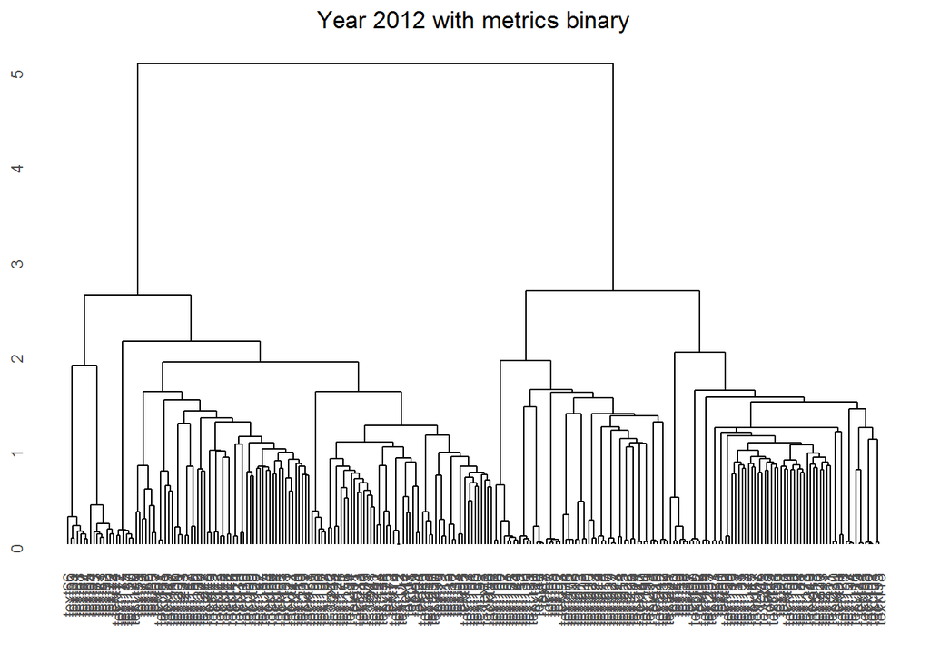

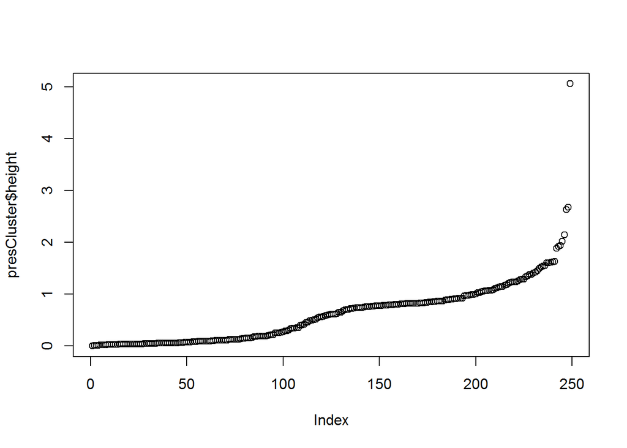

Here, the “Elbow”" is located around the level 1.5 and therefore h=1.5 is used for clustering.

#### The number of cuts:

```
## [1] "number of cuts: 18"
```

```
## cuts
##  1  4  2  5  7  3 10 14 16 11
## 51 42 41 25 11  8  8  8  8  7
```

#### Members of the 1st largest cluster.

```
##   text1   text2   text3   text4   text9  text11  text12  text13  text15
##       1       1       1       1       1       1       1       1       1
##  text17  text21  text24  text26  text32  text33  text38  text56  text61
##       1       1       1       1       1       1       1       1       1
##  text75  text76  text78  text90  text94  text95 text101 text105 text106
##       1       1       1       1       1       1       1       1       1
## text112 text113 text124 text126 text128 text134 text138 text156 text171
##       1       1       1       1       1       1       1       1       1
## text173 text174 text180 text182 text192 text233 text234 text235 text236
##       1       1       1       1       1       1       1       1       1
## text237 text238 text241 text242 text245 text246
##       1       1       1       1       1       1
```

#### Members of the 2nd largest cluster.

```
##  text10  text14  text22  text27  text42  text44  text46  text48  text59
##       4       4       4       4       4       4       4       4       4
##  text63  text64  text88 text109 text110 text121 text122 text125 text135
##       4       4       4       4       4       4       4       4       4
## text136 text139 text142 text143 text145 text146 text147 text148 text150
##       4       4       4       4       4       4       4       4       4
## text152 text154 text161 text168 text169 text183 text187 text200 text201
##       4       4       4       4       4       4       4       4       4
## text203 text239 text244 text247 text248 text250
##       4       4       4       4       4       4
```

#### Members of the 3rd largest cluster.

```
##   text5   text6  text23  text25  text28  text30  text31  text35  text47
##       2       2       2       2       2       2       2       2       2
##  text49  text50  text51  text60  text62  text99 text111 text115 text119
##       2       2       2       2       2       2       2       2       2
## text120 text123 text127 text133 text137 text141 text153 text157 text159
##       2       2       2       2       2       2       2       2       2
## text160 text164 text178 text184 text188 text189 text190 text193 text211
##       2       2       2       2       2       2       2       2       2
## text218 text220 text221 text243 text249
##       2       2       2       2       2
```

#### Members of the 4th largest cluster.

```
##  text18  text19  text41 text108 text114 text140 text191 text209 text214
##       5       5       5       5       5       5       5       5       5
## text215 text216 text217 text219 text222 text223 text224 text225 text226
##       5       5       5       5       5       5       5       5       5
## text227 text228 text229 text230 text231 text232 text240
##       5       5       5       5       5       5       5
```

#### Members of the 5th largest cluster.

```
##  text34  text73  text93  text98 text102 text103 text104 text107 text116
##       7       7       7       7       7       7       7       7       7
## text118 text165
##       7       7
```

#### Keywords for 1st largest cluster.

| word1 | word2 | word3 | count | G2 |
| --- | --- | --- | --- | --- |
| benghazi | comm |  | 166 | 1543.59335 |
| foia | waiver |  | 166 | 1543.59335 |
| house | select |  | 166 | 1543.59335 |
| select | benghazi |  | 166 | 1531.36336 |
| sensitive | information |  | 166 | 1531.36336 |
| state | dept |  | 166 | 1079.21160 |
| state | case |  | 164 | 1052.61012 |
| 2015 | state |  | 161 | 997.27090 |
| unclassified | u.s |  | 159 | 1383.41281 |
| b5 | unclassified |  | 34 | 201.17847 |
| september | 12 |  | 25 | 166.81829 |
| original | message |  | 22 | 285.76211 |
| september | 11 |  | 14 | 88.43531 |
| 6498 | b5 |  | 10 | 81.14800 |
| chris | smith |  | 8 | 103.98663 |
| september | 16 |  | 8 | 71.09478 |
| cheryl | 0 |  | 8 | 64.95579 |
| b3 | cia |  | 6 | 86.78772 |
| cia | pers |  | 6 | 86.78772 |
| great | work |  | 6 | 76.58446 |

#### Keywords for 2nd largest cluster.

| word1 | word2 | word3 | count | G2 |
| --- | --- | --- | --- | --- |
| unclassified | u.s |  | 102 | 1029.00574 |
| state | case |  | 102 | 807.61614 |
| foia | waiver |  | 96 | 1068.33317 |
| house | select |  | 96 | 1009.00405 |
| sensitive | information |  | 96 | 980.41382 |
| benghazi | comm |  | 96 | 938.86586 |
| select | benghazi |  | 96 | 872.23086 |
| state | dept |  | 96 | 766.92173 |
| 2015 | state |  | 95 | 708.63321 |
| september | 12 |  | 21 | 172.59602 |
| breaking | news |  | 15 | 203.19089 |
| november | 14 |  | 14 | 129.60805 |
| september | 14 |  | 14 | 100.68906 |
| original | message |  | 13 | 181.32896 |
| politico | breaking |  | 12 | 157.06347 |
| dry | eye |  | 11 | 170.17648 |
| david | petraeus |  | 11 | 135.75673 |
| secretary | clinton |  | 9 | 73.78952 |
| b6 | b6 |  | 9 | 56.54255 |
| december | 20 |  | 8 | 116.30483 |

#### Keywords for 3rd largest cluster.

| word1 | word2 | word3 | count | G2 |
| --- | --- | --- | --- | --- |
| state | case |  | 225 | 1936.0221 |
| unclassified | u.s |  | 224 | 2138.5052 |
| state | dept |  | 220 | 1970.9270 |
| foia | waiver |  | 218 | 2687.5375 |
| house | select |  | 218 | 2463.5692 |
| sensitive | information |  | 218 | 2458.3980 |
| benghazi | comm |  | 218 | 2199.3824 |
| select | benghazi |  | 218 | 2105.0197 |
| 2015 | state |  | 212 | 1775.8364 |
| state | department |  | 56 | 421.9682 |
| united | states |  | 41 | 577.1430 |
| foreign | policy |  | 29 | 339.2145 |
| middle | east |  | 25 | 402.3525 |
| ansar | al |  | 25 | 315.1543 |
| al | qaeda |  | 21 | 303.9094 |
| hillary | clinton |  | 20 | 219.1697 |
| white | house |  | 20 | 193.6539 |
| susan | rice |  | 17 | 209.4607 |
| chris | stevens |  | 17 | 196.3787 |
| september | 13 |  | 17 | 195.6911 |

#### Keywords for 4thlargest cluster.

| word1 | word2 | word3 | count | G2 |
| --- | --- | --- | --- | --- |
| foia | waiver |  | 180 | 2292.4047 |
| house | select |  | 180 | 2261.7889 |
| benghazi | comm |  | 180 | 2087.2136 |
| select | benghazi |  | 180 | 1966.7586 |
| sensitive | information |  | 180 | 1833.7957 |
| state | dept |  | 180 | 1744.2932 |
| state | case |  | 180 | 1684.6453 |
| unclassified | u.s |  | 179 | 1985.1007 |
| 2015 | state |  | 176 | 1660.0192 |
| sensitive | source |  | 111 | 825.2110 |
| source | comment |  | 71 | 811.0042 |
| libyan | national |  | 60 | 371.3003 |
| transitional | council |  | 56 | 748.8437 |
| national | transitional |  | 56 | 615.8508 |
| prime | minister |  | 53 | 657.8155 |
| western | intelligence |  | 51 | 436.9120 |
| muslim | brotherhood |  | 50 | 653.4086 |
| el | magariaf |  | 43 | 361.4312 |
| united | states |  | 41 | 560.1249 |
| security | services |  | 41 | 396.8437 |

#### Keywords for 5th largest cluster.

| word1 | word2 | word3 | count | G2 |
| --- | --- | --- | --- | --- |
| foia | waiver |  | 226 | 2865.5754 |
| house | select |  | 226 | 2764.5963 |
| sensitive | information |  | 226 | 2685.4016 |
| benghazi | comm |  | 226 | 2636.5793 |
| select | benghazi |  | 226 | 2470.7877 |
| state | dept |  | 226 | 2150.2119 |
| unclassified | u.s |  | 224 | 2321.2641 |
| 2015 | state |  | 224 | 2110.4698 |
| state | case |  | 224 | 2007.2601 |
| secretary | clinton |  | 221 | 2545.2806 |
| united | states |  | 140 | 1759.7447 |
| state | department |  | 43 | 368.7468 |
| chris | stevens |  | 38 | 479.6208 |
| foreign | minister |  | 37 | 400.8474 |
| ambassador | chris |  | 29 | 289.9777 |
| middle | east |  | 24 | 379.1124 |
| expeditionary | diplomacy |  | 23 | 325.4469 |
| united | nations |  | 22 | 196.3218 |
| prime | minister |  | 21 | 277.0162 |
| president | obama |  | 21 | 203.7777 |

#### Intersections from the clusters

| intersection |
| --- |
| foia waiver |
| house select |
| sensitive information |
| benghazi comm |
| select benghazi |
| unclassified u.s |
| state dept |
| 2015 state |
| state case |
| september 13 |
| jacob 3 |
| original message |
| september 12 |
| pis print |
| 36 pm |
| september 14 |
| september 11 |
| b6 b6 |
| b6 unclassified |

From the dendrograms, we can see that the similarity of Canberra and Binary metric is reflected in the results even without making a comparison between the results. Results from both metrics show very high degree of similarity both in sizes and contents of the clusters. To further investigate the similarity of the results, similarity matrices are constructed below, with each entry equal to the size of the intersection of clusters divided by the size of the union of the clusters where E stands for Euclidean, C stands for Canberra, B stands for Binary and 1, 2, 3, 4, 5 stands for the 1st largest cluster, 2nd largest cluster and so on.

### Compare Canberra with Binary

|  | C1 | C2 | C3 | C4 | C5 |
| --- | --- | --- | --- | --- | --- |
| B1 | 0.8679245 | 0.0000000 | 0.0333333 | 0 | 0.0000000 |
| B2 | 0.0227273 | 0.0470588 | 0.7500000 | 0 | 0.0000000 |
| B3 | 0.0000000 | 0.8333333 | 0.0121951 | 0 | 0.0000000 |
| B4 | 0.0000000 | 0.0000000 | 0.0000000 | 1 | 0.0000000 |
| B5 | 0.0000000 | 0.0545455 | 0.0000000 | 0 | 0.7272727 |

### Compare Euclidean with Binary

|  | E1 | E2 | E3 | E4 | E5 |
| --- | --- | --- | --- | --- | --- |
| B1 | 0.0000000 | 0.0000000 | 0.0000000 | 0.2500000 | 0.2545455 |
| B2 | 0.0957447 | 0.0000000 | 0.0000000 | 0.1578947 | 0.0714286 |
| B3 | 0.5937500 | 0.0000000 | 0.0149254 | 0.0000000 | 0.0000000 |
| B4 | 0.0000000 | 0.3947368 | 0.2380952 | 0.0000000 | 0.0000000 |
| B5 | 0.1803279 | 0.0000000 | 0.0000000 | 0.0000000 | 0.0000000 |

### Compare Euclidean with Canberra

|  | E1 | E2 | E3 | E4 | E5 |
| --- | --- | --- | --- | --- | --- |
| C1 | 0.0000000 | 0.0000000 | 0.0000000 | 0.2000000 | 0.2692308 |
| C2 | 0.6875000 | 0.0000000 | 0.0136986 | 0.0000000 | 0.0000000 |
| C3 | 0.0618557 | 0.0000000 | 0.0000000 | 0.2222222 | 0.0714286 |
| C4 | 0.0000000 | 0.3947368 | 0.2380952 | 0.0000000 | 0.0000000 |
| C5 | 0.1311475 | 0.0000000 | 0.0000000 | 0.0000000 | 0.0000000 |

### Discussion

With no surprise, the results from the similarity matrices agree with our prediction drawn from the dendrogram. C & B shows a very good agreement on clusters and their sizes with just a slight difference in 2 and 3. On the other hand, Euclidean provides a rather different result from C and B due to the major difference in distance measurement. However, from the matrix, we can still see that there is significant degree of agreement between E & C and E & B.

Also, from the size of the clusters formed, notice that there is a gradual decrease in the size of clusters for Euclidean metrics while for B & C, main clusters are formed with similar size (~ 40 emails per clusters). From the dendrogram, we can also see that B & C have a more systematic hierarchical structure than the Euclidean metric.

**Note:

As the similarity matrix is constructed without considering the frequency of words, strictly speaking, the similarity matrix comparison is somehow not fair to be applied on E as E has taken account the frequency of words. However, on the other hand, we do hope to have totally different keywords contained in different clusters and that is why such similarity comparison metric is applied.

## Investigation and Visualisation of Keywords

### Cluster 1:

In the collocation makeup, here are a some of the top keywords.

#### Names and people:

Chris Smith

Cherl

john

Chris stevens

william

Libyans

libya

#### Events objects and actions:

visas obtained

potus calls

libyans confirmed

announce tonight

clinton cites

Quick Summary

deadly riots

marie slaughter

npr report

station chief

wing extremist

formal confirmation

lte droid

CIA pers

Here is a glance of what is the sentence in the emails mentioning the verbs and words above.

| docname | position | contextPre | keyword | contextPost |
| --- | --- | --- | --- | --- |
| text1 | 13002:13003 | ‘nulandyj@state.goy’ Subject: | Chris Smith | Cheryl told me the Libyans |
| text1 | 13163:13164 | J Subject: RE: | Chris Smith | We are awaiting formal confirmation |
| text1 | 13220:13221 | , Victoria J Subject: | Chris Smith | Cheryl told me the Libyans |
| text1 | 13374:13375 | nulandvj@state.gost Subject: Re: | Chris Smith | Ok. Original Message- |
| text1 | 13420:13421 | nulandvj@state.gova Subject: RE: | Chris Smith | We are awaiting formal confirmation |
| text1 | 13475:13476 | , Victoria I Subject: | Chris Smith | Cheryl told me the Libyans |
| text1 | 13633:13634 | Cheryl D Subject Re: | Chris Smith | We need to ck family’s |
| text1 | 13726:13727 | Victoria.] Subject: | Chris Smith | Cheryl told me the Libyans |

| docname | position | contextPre | keyword | contextPost |
| --- | --- | --- | --- | --- |
| text1 | 11411 | Libya has granted agrement to | John | Christopher Stevens( goes by |
| text1 | 11825 | Google and YouTube Brennan, | John | 0. Subject: RE |
| text1 | 11928 | , Avril; Brennan, | John | 0.; Canegallo Kristie |

| docname | position | contextPre | keyword | contextPost |
| --- | --- | --- | --- | --- |
| text1 | 280:281 | Huma Subject: Re: | Chris Stevens | Thx Original Message From: |
| text1 | 325:326 | , Cheryl D Subject: | Chris Stevens | To you and all my |
| text1 | 14176:14177 | " MillsCD@state.gov’ Subject: | Chris Stevens | To you and all my |

| docname | position | contextPre | keyword | contextPost |
| --- | --- | --- | --- | --- |
| text1 | 2842 | 00 AM To Burns, | William | 3; Sherman, Wendy |
| text1 | 3088 | AM To: Burns, | William | 3; Sherman, Wendy |
| text1 | 5365 | Jacob J; Burns, | William | . 1 Subject: FW |
| text1 | 5631 | , Jacobi, Burns, | William | Subject: FW: Visas |
| text1 | 5829 | 51 AM To Burns, | William | 3; Sherman, Wendy |
| text1 | 12172 | Uzra S; Burns, | William | 3; Kennedy, Patrick |
| text1 | 12389 | shortly From: Burns, | William | Sent: Tuesday, December |

| docname | position | contextPre | keyword | contextPost |
| --- | --- | --- | --- | --- |
| text1 | 13008 | Smith Cheryl told me the | Libyans | confirmed his death. Should |
| text1 | 13226 | Smith Cheryl told me the | Libyans | confirmed his death. Should |
| text1 | 13481 | Smith Cheryl told me the | Libyans | confirmed his death. Should |
| text1 | 13732 | Smith Cheryl told me the | Libyans | confirmed his death. Should |

| docname | position | contextPre | keyword | contextPost |
| --- | --- | --- | --- | --- |
| text1 | 1679 | Fw: The Youth of | Libya | Hope. See picture below |
| text1 | 1728 | Subject: The Youth of | Libya | Libya Alhurra TV via Facebook |
| text1 | 1729 | : The Youth of Libya | Libya | Alhurra TV via Facebook UNCLASSIFIED |
| text1 | 2100 | Re: The Youth of | Libya | From: Sherman, Wendy |
| text1 | 2154 | Fw: The Youth of | Libya | Hope. See picture below |
| text1 | 2203 | Subject: The Youth of | Libya | Libya A hurra TV via |
| text1 | 2204 | : The Youth of Libya | Libya | A hurra TV via Facebook |
| text1 | 2350 | : Fwd: more on | libya | Libya 37 sept 12 12 |
| text1 | 2351 | Fwd: more on libya | Libya | 37 sept 12 12. |
| text1 | 2380 | : Fwd: more on | libya | Sending direct. Just in |
| text1 | 2405 | Message Subject: more on | libya | From: tyier drurnhener 8Liti |
| text1 | 2561 | : Fwd: more on | libya | Will do. From: |
| text1 | 2597 | : Fwd: more on | libya | We should get this around |
| text1 | 2629 | : Fwd: more on | libya | Sending direct. Just Sent |
| text1 | 2653 | - Subject: more on | libya | From: tyler druntheller& |
| text1 | 2812 | POTUS Calls to Presidents of | Libya | and Egypt FYI From: |
| text1 | 2865 | POTUS Calls to Presidents of | Libya | and Egypt FYSA Please do |
| text1 | 3016 | POTUS Calls to Presidents of | Libya | and Egypt Pis print. |
| text1 | 3059 | POTUS Calls to Presidents of | Libya | and Egypt FYI From: |
| text1 | 5379 | FBI got their visas for | Libya | today: Five members of |
| text1 | 5643 | FBI got their visas for | Libya | today: Five members of |
| text1 | 6845 | AM To: Millscd@state.gov Subject | Libya | I just heard an npr |
| text1 | 7009 | : Subject: Re: | Libya | Have not seen- will |
| text1 | 7053 | , Cheryl D Subject: | Libya | I just heard an npr |
| text1 | 11400 | . Subject: Agra:rent/ | Libya | Sensitive Doug, Collin: |
| text1 | 11406 | Sensitive Doug, Collin: | Libya | has granted agrement to John |
| text1 | 12610 | Henri- Levi’s film about | Libya | ? I think Harvey made |
| text1 | 14038 | with this painful tragedy in | Libya | . Warmest, Maria UNCLASSIFIED |
| text1 | 14344 | 2012 8: 54 AM | Libya | B6 The news from Libya |
| text1 | 14349 | Libya B6 The news from | Libya | is truly shocking. Just |

| docname | position | contextPre | keyword | contextPost |
| --- | --- | --- | --- | --- |
| text1 | 5317:5318 | To: Subject FW: | Visas Obtained | – Original Message- |
| text1 | 5372:5373 | 1 Subject: FW: | Visas Obtained | FBI got their visas for |
| text1 | 5540:5541 | rnillscd@state.gov’ Subject Re: | Visas Obtained | As planned… |
| text1 | 5581:5582 | H Subject: FW: | Visas Obtained | —- Original |
| text1 | 5636:5637 | William Subject: FW: | Visas Obtained | FBI got their visas for |

| docname | position | contextPre | keyword | contextPost |
| --- | --- | --- | --- | --- |
| text1 | 2807:2808 | RV: Quick Summary of | POTUS Calls | to Presidents of Libya and |
| text1 | 2860:2861 | FW: Quick Summary of | POTUS Calls | to Presidents of Libya and |
| text1 | 3011:3012 | Fw: Quick Summary of | POTUS Calls | to Presidents of Libya and |
| text1 | 3054:3055 | FW: Quick Summary of | POTUS Calls | to Presidents of Libya and |
| text1 | 3107:3108 | FW: Quick Summary of | POTUS Calls | to Presidents of Ubya and |

| docname | position | contextPre | keyword | contextPost |
| --- | --- | --- | --- | --- |
| text1 | 13015:13016 | his death. Should we | announce tonight | or wait until morning? |
| text1 | 13233:13234 | his death. Should we | announce tonight | or wait until morning? |
| text1 | 13488:13489 | his death. Should we | announce tonight | or wait until morning? |
| text1 | 13739:13740 | his death. Should we | announce tonight | or wait until morning? |

| docname | position | contextPre | keyword | contextPost |
| --- | --- | --- | --- | --- |
| text1 | 11030:11031 | Subject Re: N’YT: | Clinton Cites | Clear Link Betwe We are |
| text1 | 11085:11086 | J Subject: NYT: | Clinton Cites | Clear Link Betwe Well, |

| docname | position | contextPre | keyword | contextPost |
| --- | --- | --- | --- | --- |
| text1 | 2804:2805 | To: Subject RV: | Quick Summary | of POTUS Calls to Presidents |
| text1 | 2857:2858 | Jacob Subject: FW: | Quick Summary | of POTUS Calls to Presidents |
| text1 | 3008:3009 | Russorv@state.govÂ° Subject Fw: | Quick Summary | of POTUS Calls to Presidents |
| text1 | 3051:3052 | I Subject: FW: | Quick Summary | of POTUS Calls to Presidents |
| text1 | 3104:3105 | ] Subject: FW: | Quick Summary | of POTUS Calls to Presidents |

| docname | position | contextPre | keyword | contextPost |
| --- | --- | --- | --- | --- |
| text1 | 1012:1013 | - fvluslim Film That Sparked | Deadly Riots | From[ meat) Sent |
| text1 | 1047:1048 | - Muslim Film That Sparked | Deadly Riots | htte/ maxbiumenthal.com12012/ 09 |

| docname | position | contextPre | keyword | contextPost |
| --- | --- | --- | --- | --- |
| text1 | 289:290 | Message From: Anne- | Marie Slaughter | [ Sent: Wednesday, |
| text1 | 14153:14154 | B6 From: Anne- | Marie Slaughter | Sent Wednesday, September 12 |

| docname | position | contextPre | keyword | contextPost |
| --- | --- | --- | --- | --- |
| text1 | 1003:1004 | : Meet The Right- | Wing Extremist | Behind Anti- fvluslim Film |
| text1 | 1038:1039 | Subject: Meet The Right | Wing Extremist | Behind Anti- Muslim Film |

| docname | position | contextPre | keyword | contextPost |
| --- | --- | --- | --- | --- |
| text1 | 6355:6356 | IN PART B5, B3 | CIA PERS | / ORG, B6 From |
| text1 | 6442:6443 | : 08 AM To B3 | CIA PERS | / ORG B6 Sullivan. |
| text1 | 6585:6586 | IN PART B5, B3 | CIA PERS | / ORG, B6 From |
| text1 | 6682:6683 | 08 AM To: B3 | CIA PERS | / ORG B6 Sullivan, |
| text1 | 11602:11603 | Cheryl D Fw: B3 | CIA PERS | / ORG B6 Subject: |
| text1 | 11688:11689 | IN PART B5, B3 | CIA PERS | / ORG, B6 From |

Based on the glance above, this clusters is generally talking about the death of Chris in Libya during the terrorist attack. His death was confirmed by the Libyans and the FBI teams had received a visa from Libya for investigation. They also talked about whether they should announce his death that night. In the emails, Chris stevens was named as Chris Smith as well. The event was sparked by the Right-Wing Extremists behind the anti-Muslim Film sparked the deadly attack. The emails also included some quick summary of the posts calls to the presidents of Libya.

To confirm the story online for the event and here are the links:

http://www.newsmax.com/TheWire/hillary-clinton-benghazi-hearing-revelations/2015/10/23/id/697712/

http://townhall.com/columnists/benshapiro/2015/10/28/no-hillary-didnt-care-about-chris-stevens-n2071864

The collocation “Chris Smith” is uniquely captured by this clusters. This clusters contains emails that contains the email communication when the attack just happened.

#### Here is the top 100 collocations of cluster 1:

[output not shown]

[output cut: 70 more lines]

### Cluster 2:

In the collocation makeup, here are a some of the top keywords.

#### Names and people:

david petraeus

secretary clinton

hillary clinton

intelligence committee

victoria

cheryl

#### Events objects and actions:

politico breaking

reuters query

senate intelligence

quick reuters

command center

amb stevens

terrorist attack

muslim film

targets hillary

warned embassy

intelligence warned

| docname | position | contextPre | keyword | contextPost |
| --- | --- | --- | --- | --- |
| text1 | 8698:8699 | Philippe Subject: FW: | David Petraeus | will testify on Benghazi( |
| text1 | 8751:8752 | Mills, Cheryl D Subject | David Petraeus | will testify on Benghazi( |
| text1 | 8760:8761 | on Benghazi( Politico) | David Petraeus | will testify on Benghazi By |
| text1 | 8791:8792 | 54 AM EST Gen. | David Petraeus | wil! testify before the |
| text1 | 9956:9957 | Jacob Subject: Re: | David Petraeus | will testify on Benghazi( |
| text1 | 10028:10029 | I Subject: FW: | David Petraeus | will testify on Benghazi( |
| text1 | 10082:10083 | , Cheryl D Subject: | David Petraeus | will testify on Benghazi( |
| text1 | 10091:10092 | on Benghazi( Politico) | David Petraeus | will testify on Benghazi By |
| text1 | 10125:10126 | 54 AM EST Gen. | David Petraeus | will testify before the Senate |
| text1 | 10826:10827 | POLITICO Breaking News Gen. | David Petraeus | will testify Friday before the |
| text1 | 11202:11203 | News POLITICO Breaking News Gen | David Petraeus | will testify Friday before the |

| docname | position | contextPre | keyword | contextPost |
| --- | --- | --- | --- | --- |
| text1 | 1459:1460 | President Â° barna, | Secretary Clinton | , and the families of |
| text1 | 4076:4077 | Republicans using taxpayer money against | Secretary Clinton | , as a partisan weapon |
| text1 | 12043:12044 | her opening statement:“ | Secretary Clinton | is committed to testifying before |
| text1 | 15133:15134 | that in my view, | Secretary Clinton | , when she said she |
| text1 | 15176:15177 | , I have never seen | Secretary Clinton | back down from a fight |
| text1 | 15508:15509 | that in my view, | Secretary Clinton | , when she said she |
| text1 | 15551:15552 | , I have never seen | Secretary Clinton | , back down from a |
| text1 | 15864:15865 | that in my view, | Secretary Clinton | , when she said she |
| text1 | 15908:15909 | , I have never seen | Secretary Clinton | back down from a fight |

| docname | position | contextPre | keyword | contextPost |
| --- | --- | --- | --- | --- |
| text1 | 3984:3985 | yet, Secretary of State | Hillary Clinton | . The story is correct |
| text1 | 11521:11522 | now: Secretary of State | Hillary Clinton | will testify before Congress on |
| text1 | 11587:11588 | committee that Secretary of State | Hillary Clinton | would be testifying before them |
| text1 | 12166:12167 | FOX reporting: Urgent: | Hillary Clinton | totestify before Congress on Benghazi |
| text1 | 15086:15087 | Department that Secretary of State | Hillary Clinton | will testify on Benghazi before |
| text1 | 15461:15462 | Department that Secretary of State | Hillary Clinton | will testify on Benghazi before |
| text1 | 15817:15818 | Department that Secretary of State | Hillary Clinton | will testify on Benghazi before |
| text1 | 17108:17109 | and please thank Mrs. | Hillary Clinton | on behalf of me and |

| docname | position | contextPre | keyword | contextPost |
| --- | --- | --- | --- | --- |
| text1 | 8799:8800 | ! testify before the Senate | Intelligence Committee | . Senate intelligence Committee Chairwoman |
| text1 | 8803:8804 | Senate Intelligence Committee. Senate | intelligence Committee | Chairwoman i3rianne Feinstein told POLMCO |
| text1 | 8914:8915 | closed hearings before the Senate | Intelligence Committee | On Thursday. Feinstein, |
| text1 | 8926:8927 | the chairwoman of the Senate | Intelligence Committee | , said on CNN’s“ |
| text1 | 10132:10133 | will testify before the Senate | Intelligence Committee | , Senate Intelligence Committee Chairwoman |
| text1 | 10136:10137 | Senate Intelligence Committee, Senate | Intelligence Committee | Chairwoman Dianne Feinstein told POLITICO |
| text1 | 10255:10256 | closed hearings before the Senate | Intelligence Committee | on Thursday. Feinstein, |
| text1 | 10267:10268 | the chairwoman of the Senate | Intelligence Committee | , said on CNN’s“ |

| docname | position | contextPre | keyword | contextPost |
| --- | --- | --- | --- | --- |
| text1 | 3183 | film From: Nuland, | Victoria | Sent: Saturday, September |
| text1 | 3269 | PM To: Nuland, | Victoria | 3 Subject CNN: US |
| text1 | 3807 | mistake From: Nuland, | Victoria | J Sent: Wednesday, |
| text1 | 11493 | David S Cc Nuland, | Victoria | 3; Hammer, Michael |
| text1 | 11738 | David S Cc Nuland, | Victoria | 3; Hammer, Michael |
| text1 | 11954 | David Cc: Nuland, | Victoria | 3; Hammer, Michael |
| text1 | 12010 | Cheryl Cc: Nuland, | Victoria | ), Hammer, Michael |
| text1 | 12102 | Cheryl Cc: Nuland, | Victoria | 3; Hammer, Michael |
| text1 | 13755 | 26 PM To. Nuland | Victoria | 3’ Peiton, Erin |
| text1 | 16124 | D; Nulane!, | Victoria | 3; Sullivan, Stephanie |

| docname | position | contextPre | keyword | contextPost |
| --- | --- | --- | --- | --- |
| text1 | 57 | FULL From: Mills, | Cheryl | 0< MillsCD@state.govâ º |
| text1 | 112 | PM To: Mills, | Cheryl | D Subject: RE: |
| text1 | 199 | . From: Mills, | Cheryl | Sent: Wednesday, September |
| text1 | 249 | 09 AM To Mills, | Cheryl | D., Sullivan, |
| text1 | 786 | B6 From: Mills, | Cheryl | 0< MillsCD@stategov> Sent |
| text1 | 834 | 09 PM To Mills, | Cheryl | I); Jones, |
| text1 | 1817 | IN FULL From Mills, | Cheryl | D< MillsCD@state.govâ º |
| text1 | 1866 | PM To: Mills, | Cheryl | D Subject: thanks Cheryl |
| text1 | 1871 | Cheryl D Subject: thanks | Cheryl | , Please extend our thanks |
| text1 | 2078 | B6 From: Mills, | Cheryl | ID< MillsCD@state.gov> Sent |
| text1 | 2128 | PM To: Mills, | Cheryl | D Subject: Re: |
| text1 | 2134 | D Subject: Re: | Cheryl | , I can’t imagine what |
| text1 | 2398 | B6 From: Mills, | Cheryl | D< MillsCD@state.gov> Sent |
| text1 | 2438 | PM To: Mills, | Cheryl | D Subject: Remarks Good |
| text1 | 3143 | FULL From: Mills, | Cheryl | D< MillsCD@state.govâ º |
| text1 | 3214 | Eric 3; Mills, | Cheryl | D; Goldberg, Philip |
| text1 | 3771 | FULL From: Mills, | Cheryl | D< MillsCD@state.gov> Sent |
| text1 | 3830 | Philippe I; Mills, | Cheryl | D; Sullivan, Jacob |
| text1 | 4758 | FULL From: Mills, | Cheryl | D< MilLsCD@state.govâ º |
| text1 | 6074 | : Subject: Mills, | Cheryl | D< MillsCD@state.gov> Thursday |
| text1 | 6131 | Jacob J; Mills, | Cheryl | D; Macmanus, Joseph |
| text1 | 7125 | FULL From: Mills, | Cheryl | D< MillsCD@state.goy> Sent |
| text1 | 7788 | . From: Mills, | Cheryl | D[ mailto:MillsCD@state.gov] Sent |
| text1 | 7840 | PM To: Mills, | Cheryl | D Subject: RE: |
| text1 | 7928 | . From: Mills, | Cheryl | D Sent: Wednesday, |
| text1 | 7981 | AM To: Mills, | Cheryl | D; Sullivan, Jacob |
| text1 | 8665 | FULL From: Mills. | Cheryl | 0< ivtillsCD@stategovâ º |
| text1 | 8748 | Patrick F; Mills, | Cheryl | D Subject David Petraeus will |
| text1 | 9104 | Message From: Mills, | Cheryl | 0 finallto:MillsCD@state, govi Sent |
| text1 | 9158 | PM To: Mills, | Cheryl | D Subject: Re: |
| text1 | 9164 | D Subject: Re: | Cheryl | , I can’t imagine what |
| text1 | 9667 | . From: Mills, | Cheryl | D[ mailto:MillsCDOstate.govj Sent: |
| text1 | 9715 | PM To: Mills, | Cheryl | D Subject: thanks Cheryl |
| text1 | 9720 | Cheryl D Subject: thanks | Cheryl | , Please extend our thanks |
| text1 | 9943 | AM To: Mills, | Cheryl | D; H Cc: |
| text1 | 9993 | briefings From: Mills, | Cheryl | D Sent: Wednesday, |
| text1 | 10078 | Patrick F; Mills, | Cheryl | D Subject: David Petraeus |
| text1 | 10446 | . From: Mills, | Cheryl | D[ mailba:MillsCD© state.govi |
| text1 | 10494 | PM To: Mills, | Cheryl | D Subject: Remarks Good |
| text1 | 10692 | FULL From: Mills, | Cheryl | 0< MillsC0@state.govâ º |
| text1 | 10739 | 04 PM To Mills, | Cheryl | D; Reines, Philippe |
| text1 | 11072 | Feinstein? From Mills, | Cheryl | D[ mailto:MillsCa© state.govj |
| text1 | 11121 | 04 PM To Mills, | Cheryl | a; Reines, Philippe |
| text1 | 11405 | B6 From: Mills, | Cheryl | D< MillsCD@state.gov> Sent |
| text1 | 11469 | 16 PM To Mills, | Cheryl | D; Toner, Mark |
| text1 | 11617 | and Chief of Staff, | Cheryl | Mills, and the Secretary |
| text1 | 11703 | december#ixzz2CJC112Z1 From: Mills, | Cheryl | D Sent: Thursday November |
| text1 | 11944 | Philippe I; Mills, | Cheryl | 0; Adams, David |
| text1 | 12005 | Philippe I; Mills, | Cheryl | Cc: Nuland, Victoria |
| text1 | 12097 | Philippe I; Mills, | Cheryl | Cc: Nuland, Victoria |
| text1 | 13198 | B6 From: Mills, | Cheryl | D-: MilisCD@stategov> |
| text1 | 13246 | PM To: Mills, | Cheryl | D; Sullivan, Jacob |
| text1 | 13713 | : Subject: Mills, | Cheryl | 0< MillsCD@state.gov> Friday |
| text1 | 14311 | PM To: Mills, | Cheryl | D Subject: Re: |
| text1 | 14379 | B6 From: Mills, | Cheryl | 0eMillsCD@state.gov> Sent: Monday |
| text1 | 14422 | Message From: Mills, | Cheryl | D[ mailto:MillsCD@stategov] Sent |
| text1 | 14502 | PM To: Mills, | Cheryl | Subject: RE: Hearings |
| text1 | 14508 | Subject: RE: Hearings | Cheryl | – I’m just following |
| text1 | 14613 | - From: Mills, | Cheryl | D[ mailto:MillsCD@state.gov] Sent |
| text1 | 14820 | PM To: Mills, | Cheryl | D Subject: Hearings Cheryl |
| text1 | 14825 | Cheryl D Subject: Hearings | Cheryl | â This is |
| text1 | 15012 | FULL From: Mills, | Cheryl | D< MillsCD@state.gov> Sent |
| text1 | 15062 | AM To: Mills, | Cheryl | D Subject: FOX from |
| text1 | 15375 | " From: Mills, | Cheryl | D[ mailto:MillsCD@state.gov] Sent |
| text1 | 15437 | AM To: Mills, | Cheryl | D Subject: FOX from |
| text1 | 15733 | ? From: Mills, | Cheryl | D[ mailto:MillsCD@state.govi Sent: |
| text1 | 16054 | FULL From: Mills, | Cheryl | D< MillsCD@state.gov> Sent |
| text1 | 16118 | Elizabeth L; Mills, | Cheryl | D; Nulane!, |
| text1 | 16661 | AM To: Mills, | Cheryl | D; Sullivan, Jacob |

| docname | position | contextPre | keyword | contextPost |
| --- | --- | --- | --- | --- |
| text1 | 10755:10756 | B Subject: FW: | POLITICO Breaking | News- From: Blumenfeld |
| text1 | 10784:10785 | Coordination Subject: Fw: | POLITICO Breaking | News.. _. |
| text1 | 10793:10794 | . _.. From | POLITICO Breaking | News Driailto:breakingnews@politico.corn] Sent: |
| text1 | 10818:10819 | , Joshua R Subject: | POLITICO Breaking | News POLITICO Breaking News Gen |
| text1 | 10821:10822 | Subject: POLITICO Breaking News | POLITICO Breaking | News Gen. David Petraeus |
| text1 | 11058:11059 | aliilscd@state.gov’ Subject Re: | POLITICO Breaking | News When will he do |
| text1 | 11097:11098 | : H Subject Fw: | POLITICO Breaking | News From: Johnson, |
| text1 | 11137:11138 | B Subject: FW: | POLITICO Breaking | News From Blumenfeld, Joshua |
| text1 | 11164:11165 | Coordination Subject: Fw: | POLITICO Breaking | News From: POLITICO Breaking |
| text1 | 11169:11170 | POLITICO Breaking News From: | POLITICO Breaking | News[ mailto:breakingnevvs@politico.com] Sent |
| text1 | 11195:11196 | , Joshua R Subject: | POLITICO Breaking | News POLITICO Breaking News Gen |
| text1 | 11198:11199 | Subject: POLITICO Breaking News | POLITICO Breaking | News Gen David Petraeus will |

| docname | position | contextPre | keyword | contextPost |
| --- | --- | --- | --- | --- |
| text1 | 11446:11447 | FW: Mark- quick | Reuters query | From: Klevorick, Caitlin |
| text1 | 11509:11510 | RE: Mark- quick | Reuters query | Here’s what fox has up |
| text1 | 11755:11756 | RE: Mark- quick | Reuters query | Yes I spoke with Rep |
| text1 | 11971:11972 | RE: Mark- quick | Reuters query | + Dave From: Lieberman |
| text1 | 12024:12025 | Libya Subject RE Mark quick | Reuters query | At the HFAC public hearing |
| text1 | 12118:12119 | FW: Mark- quick | Reuters query | Hi all- Do we |
| text1 | 12157:12158 | Subject: Mark- quick | Reuters query | We see FOX reporting: |

| docname | position | contextPre | keyword | contextPost |
| --- | --- | --- | --- | --- |
| text1 | 8798:8799 | wil! testify before the | Senate Intelligence | Committee. Senate intelligence Committee |
| text1 | 8802:8803 | the Senate Intelligence Committee. | Senate intelligence | Committee Chairwoman i3rianne Feinstein told |
| text1 | 8913:8914 | at closed hearings before the | Senate Intelligence | Committee On Thursday. Feinstein |
| text1 | 8925:8926 | , the chairwoman of the | Senate Intelligence | Committee, said on CNN’s |
| text1 | 10131:10132 | Petraeus will testify before the | Senate Intelligence | Committee, Senate Intelligence Committee |
| text1 | 10135:10136 | the Senate Intelligence Committee, | Senate Intelligence | Committee Chairwoman Dianne Feinstein told |
| text1 | 10254:10255 | at closed hearings before the | Senate Intelligence | Committee on Thursday. Feinstein |
| text1 | 10266:10267 | , the chairwoman of the | Senate Intelligence | Committee, said on CNN’s |

| docname | position | contextPre | keyword | contextPost |
| --- | --- | --- | --- | --- |
| text1 | 11445:11446 | : FW: Mark- | quick Reuters | query From: Klevorick, |
| text1 | 11508:11509 | Subject RE: Mark- | quick Reuters | query Here’s what fox has |
| text1 | 11754:11755 | : RE: Mark- | quick Reuters | query Yes I spoke with |
| text1 | 11970:11971 | : RE: Mark- | quick Reuters | query+ Dave From: |
| text1 | 12023:12024 | PA Libya Subject RE Mark | quick Reuters | query At the HFAC public |
| text1 | 12117:12118 | Subject FW: Mark- | quick Reuters | query Hi all- Do |
| text1 | 12156:12157 | C Subject: Mark- | quick Reuters | query We see FOX reporting |

| docname | position | contextPre | keyword | contextPost |
| --- | --- | --- | --- | --- |
| text1 | 16227:16228 | now. From: DS | Command Center | Sent: Tuesday, September |
| text1 | 16248:16249 | SIES- 0 Cc DS | Command Center | ; DSCC_Management Team Subject: |
| text1 | 16265:16266 | Benghazi ALCON: The DS | Command Center | is sharing the following event |
| text1 | 16281:16282 | . Please contact the DS | Command Center | directly for any follow- |
| text1 | 16343:16344 | incident report from the DS | Command Center | . The information contained in |
| text1 | 16379:16380 | Please protect accordingly. DS | Command Center | UNCLASSIFIED U.S. Department of |

| docname | position | contextPre | keyword | contextPost |
| --- | --- | --- | --- | --- |
| text1 | 808:809 | : Subject: Fw: | Amb Stevens | Remind me to discuss From |
| text1 | 866:867 | L Subject: RE: | Amb Stevens | I just wanted to let |
| text1 | 969:970 | peciaIAssistants Subject: FW: | Amb Stevens | NEA says he told Beth |
| text1 | 1053:1054 | DL Subject: RE: | Amb Stevens | Importance: High 12, |
| text1 | 1209:1210 | 0; SES DutyDeputies Subject | Amb Stevens | S Specials, per your |

| docname | position | contextPre | keyword | contextPost |
| --- | --- | --- | --- | --- |
| text1 | 13802:13803 | the intelligence related to the | terrorist attack | on the U.S. consulate |
| text1 | 13818:13819 | In the aftermath of the | terrorist attack | on U.S. personnel and |
| text1 | 14003:14004 | was a deliberate and organized | terrorist attack | carried out by extremists. |
| text1 | 14100:14101 | of the circumstances surrounding the | terrorist attack | . We continue to support |
| text1 | 14119:14120 | Department review of the Benghazi | terrorist attack | , pmviding the full capabilities |

| docname | position | contextPre | keyword | contextPost |
| --- | --- | --- | --- | --- |
| text1 | 3177:3178 | Egypt of concern about anti | Muslim film | From: Nuland, Victoria |
| text1 | 3241:3242 | of concern about anti- | Muslim film | Here we go.. |
| text1 | 3285:3286 | of concern about anti- | Muslim film | Hey, have you had |
| text1 | 3332:3333 | reaction to an anti- | Muslim film | that was gaining attention online |

| docname | position | contextPre | keyword | contextPost |
| --- | --- | --- | --- | --- |
| text1 | 3798:3799 | : The Hill: Issa | targets Hillary | : Big mistake From: |
| text1 | 3845:3846 | : The Hill: Issa | targets Hillary | : Big mistake From: |
| text1 | 3924:3925 | : The Hill: Issa | targets Hillary | : Big mistake Issa targets |
| text1 | 3930:3931 | Hillary: Big mistake Issa | targets Hillary | : Big mistake By Brent |

| docname | position | contextPre | keyword | contextPost |
| --- | --- | --- | --- | --- |
| text1 | 3169:3170 | : FW: US intelligence | warned embassy | in Egypt of concern about |
| text1 | 3232:3233 | : Fw: US intelligence | warned embassy | in Egypt of concern about |
| text1 | 3276:3277 | Subject CNN: US intelligence | warned embassy | in Egypt of concern about |
| text1 | 3309:3310 | ?- E VS intelligence | warned embassy | in Egypt of concern, |

| docname | position | contextPre | keyword | contextPost |
| --- | --- | --- | --- | --- |
| text1 | 3168:3169 | Subject: FW: US | intelligence warned | embassy in Egypt of concern |
| text1 | 3231:3232 | Subject: Fw: US | intelligence warned | embassy in Egypt of concern |
| text1 | 3275:3276 | 3 Subject CNN: US | intelligence warned | embassy in Egypt of concern |
| text1 | 3308:3309 | saying?- E VS | intelligence warned | embassy in Egypt of concern |

To confirm the story online for the event and here are the links:

http://www.newsmax.com/Newsfront/darrell-issa-fbi-no-choice/2016/02/03/id/712612/

http://www.newsmax.com/Newsfront/rand-paul-hillary-clinton-david-petraeus-email-scandal/2016/01/26/id/710973/

https://news.vice.com/article/government-finds-emails-with-david-petraeus-that-hillary-clinton-didnt-hand-over

https://www.aei.org/publication/demote-petraeus-while-clinton-seeks-a-promotion-to-commander-in-chief/

#### Here is the top 100 collocations of cluster 2:

[output not shown]

[output cut: 70 more lines]

### Cluster 3:

#### Names and people:

ansar al

al qaeda

hillary clinton

middle east

white house

chris stevens

security forces

prime minister

mitt romney

consulate general

susan rice

ambassador susan

abu khattala

local militia

islamist militias

department official

president obama

security council

#### Events objects and actions:

foreign policy

11 attacks

compare benghazi

diplomatic security

national security

hrc travels

nuclear weapon

default setting

cnn belief

abc news

kuwait city

intelligence community

terrorist attack

libyan officials

| docname | position | contextPre | keyword | contextPost |
| --- | --- | --- | --- | --- |
| text1 | 16408:16409 | by the Benghazi chapter of | Ansar al | - Sharia, an extremist |
| text1 | 18169:18170 | by the Benghazi chapter of | Ansar al | - Sharia, an extremist |
| text1 | 27247:27248 | supporters of hardline Islamist group | Ansar al | - Sharia were waiting. |
| text1 | 27795:27796 | linked to the attack is | Ansar al | - Shatia, which has |
| text1 | 27817:27818 | , a demonstrator at the | Ansar al | - Sharia counter demonstration, |
| text1 | 28466:28467 | were many people there from | Ansar al | - Shariah, from other |
| text1 | 28528:28529 | denied being a leader of | Ansar al | - Shariah, but said |
| text1 | 28567:28568 | in the group.“ | Ansar al | - Shariah is a factionalised |
| text1 | 29207:29208 | joined other brigades, including | Ansar al | - Shariah in Benghazi. |
| text1 | 29548:29549 | overwhelmed the compound of the | Ansar Al | - Sharlah Brigade in the |
| text1 | 29563:29564 | eastern city of Benghazi. | Ansar Al | - Shariah fighters initially fired |
| text1 | 29823:29824 | up of Islamic radicals like | Ansar Al | - Shariah are notorious for |
| text1 | 29847:29848 | and witnesses say fighters from | Ansar Al | - Shariati led the attack |
| text1 | 29954:29955 | gates of the headquarters of | Ansar Al | - Shariah." No |
| text1 | 30278:30279 | begun to stand up against | Ansar Al | - Shariah and other militias |
| text1 | 30395:30396 | residents are lashing out against | Ansar Al | - Shariah, the main |
| text1 | 30719:30720 | And many are impatient with | Ansar Al | - Sharjah’s talk of imposing |
| text1 | 30964:30965 | he added, referring to | Ansar Al | - Shariah’s black banner. |
| text1 | 34694:34695 | men as" afraid of | Ansar al | Shariah.“” Everyone |
| text1 | 36513:36514 | supporters of hardline Islamist group | Ansar al | - Sharia were waiting. |
| text1 | 37064:37065 | linked to the attack is | Ansar al | - Sharia, which has |
| text1 | 37086:37087 | , a demonstrator at the | Ansar al | - Sharia counter demonstration, |
| text1 | 39684:39685 | members of the jihaclist militia | Ansar al | - Shariah turned on the |
| text1 | 41218:41219 | members of the jihadist militia | Ansar al | - Shariah turned on the |
| text1 | 43536:43537 | the assault to leaders of | Ansar al | - Sharia, a loose |

| docname | position | contextPre | keyword | contextPost |
| --- | --- | --- | --- | --- |
| text1 | 9916:9917 | I passed that wall after | Al Qaeda | blew up two American Embassies |
| text1 | 12147:12148 | politically inconvenient to note that | al Qaeda | is far from UNCLASSIFIED U.S |
| text1 | 13588:13589 | was the work of an | al Qaeda | offshoot. The White House |
| text1 | 16044:16045 | was probably the work of | al Qaeda | , the same group that |
| text1 | 18182:18183 | thought to have ties to | Al Qaeda | in the Islamic Magreb( |
| text1 | 30383:30384 | Emirate and ally itself with | Al Qaeda | . But now, the |
| text1 | 30952:30953 | don’t want the flag of | Al Qaeda | raised over heads,“ |
| text1 | 31768:31769 | government protests in 2011, | al Qaeda | in the Arabian Peninsula( |
| text1 | 32219:32220 | well as reaching out to | al Qaeda | . They have one goal |
| text1 | 32254:32255 | of the religious spectrum, | al Qaeda | and Iran will cooperate, |
| text1 | 32275:32276 | indications that Iran is helping | al Qaeda | by trying to forge relations |
| text1 | 35900:35901 | act of terrorism and that | al Qaeda | may have played a role |
| text1 | 40315:40316 | into the vacuum, while | al Qaeda | - style training camps proliferate |
| text1 | 41847:41848 | into the vacuum, while | al Qaeda | - style training camps proliferate |
| text1 | 44209:44210 | / 11. Decades after | al Qaeda | attacked our embassies in East |
| text1 | 44255:44256 | Clearly, the threat from | al Qaeda | and affiliated groups has metastasized |
| text1 | 47224:47225 | that says there are 10 | Al Qaeda | militia roaming around and we |
| text1 | 49048:49049 | that says there are 10 | Al Qaeda | militia roaming around and we |
| text1 | 49979:49980 | , given that there were | Al Qaeda | sympathizers among the rebel army |
| text1 | 50136:50137 | affiliated with or sympathized with | Al Qaeda | , why did she push |
| text1 | 50399:50400 | admitting that it was an | Al Qaeda | attack would destroy the narrative |

| docname | position | contextPre | keyword | contextPost |
| --- | --- | --- | --- | --- |
| text1 | 3252:3253 | ," Secretary of State | Hillary Clinton | added." The United |
| text1 | 4420:4421 | FW: Wash Post: | Hillary Clinton | tries to calm at i |
| text1 | 4476:4477 | FW: Wash Post: | Hillary Clinton | tries to calm anti- |
| text1 | 4542:4543 | Affairs Subject Wash Post: | Hillary Clinton | tries to calm anti- |
| text1 | 4558:4559 | protesters storm embassy in Yemen | Hillary Clinton | tries to calm anti- |
| text1 | 13629:13630 | Obama’s nominating her to succeed | Hillary Clinton | as secretary of State. |
| text1 | 14695:14696 | ," Secretary of State | Hillary Clinton | added." The United |
| text1 | 16440:16441 | affiliate. Secretary of State | Hillary Clinton | suggested that groups with links |
| text1 | 18201:18202 | affiliate. Secretary of State | Hillary Clinton | suggested that groups with links |
| text1 | 22111:22112 | Obama and Secretary of State | Hillary Clinton | led the solemn ceremony, |
| text1 | 22499:22500 | unexpected defeat, a different | Hillary Clinton | began to emerge. She |
| text1 | 22649:22650 | tiny moment. Still, | Hillary Clinton | rose to meet it. |
| text1 | 23878:23879 | lawmakers by Secretary of State | Hillary Clinton | Thursday, Sen. Susan |
| text1 | 33993:33994 | Stevens, Secretary of State | Hillary Clinton | said that the administration has |
| text1 | 35561:35562 | Ambassador Susan Rice to succeed | Hillary Clinton | as Secretary of State. |
| text1 | 35759:35760 | Ambassador Susan Rice to succeed | Hillary Clinton | as Secretary of State. |
| text1 | 39306:39307 | missing from Congressional scrutiny: | Hillary Clinton | . GOP Congressman Peter King |
| text1 | 40821:40822 | missing from Congressional serAny: | Hillary Clinton | . GOP Congressman Peter Kin |
| text1 | 42433:42434 | to replace Secrretary of State | Hillary Clinton | , who is not expected |
| text1 | 51229:51230 | not the State Department. | Hillary Clinton | is about to retire, |

| docname | position | contextPre | keyword | contextPost |
| --- | --- | --- | --- | --- |
| text1 | 1742:1743 | fell in love with the | Middle East | as a young Peace Corps |
| text1 | 5145:5146 | raised questions about whether vulnerable | Middle East | governments are willing or even |
| text1 | 7161:7162 | SITUATION REPORT No. I | Middle East | Protests Monitoring Group MGMEPO1 Friday |
| text1 | 8517:8518 | SITUATION REPORT No. I | Middle East | Protests Monitoring Group MGMEPO1 Friday |
| text1 | 10072:10073 | heads began to expound on | Middle East | policies and the words administration |
| text1 | 16097:16098 | playing out across the broader | Middle East | – a region that |
| text1 | 16361:16362 | to control much of the | Middle East | today; and who seek |
| text1 | 16517:16518 | the rapid changes in the | Middle East | with a proactive and coherent |
| text1 | 16551:16552 | , and a more prosperous | Middle East | allied with the United States |
| text1 | 16588:16589 | defeat our enemies in the | Middle East | when our words are not |
| text1 | 16646:16647 | to change come in the | Middle East | ." Romney will promise |
| text1 | 17169:17170 | of Barack Obama in the | Middle East | is a mess and is |
| text1 | 17857:17858 | playing out across the broader | Middle East | – a region that |
| text1 | 18121:18122 | to control much of the | Middle East | today; and who seek |
| text1 | 18280:18281 | the rapid changes in the | Middle East | with a proactive and coherent |
| text1 | 18314:18315 | , and a more prosperous | Middle East | allied with the United States |
| text1 | 18351:18352 | defeat our enemies in the | Middle East | when our words are not |
| text1 | 18411:18412 | to change course in the | Middle East | ." Romney will promise |
| text1 | 18935:18936 | of Barack Obama in the | Middle East | is a mess and is |
| text1 | 20029:20030 | what’s gone on in the | Middle East | in Arab countries and elsewhere |
| text1 | 20434:20435 | is going on in the | Middle East | now and say that the |
| text1 | 22226:22227 | keep peace in a smoldering | Middle East | . It was a line |
| text1 | 38026:38027 | leaving a mark on the | Middle East | , Petraeus helped design a |
| text1 | 45831:45832 | Like the fanatics in the | Middle East | and North Africa, our |
| text1 | 57046:57047 | with the people of the | Middle East | and North Africa which began |

| docname | position | contextPre | keyword | contextPost |
| --- | --- | --- | --- | --- |
| text1 | 5344:5345 | of the attack, the | White House | said. In Brussels, |
| text1 | 11906:11907 | Also, what did the | White House | think it had to gain |
| text1 | 13593:13594 | al Qaeda offshoot. The | White House | had fumbled key intelligence information |
| text1 | 13833:13834 | it handed to her by | White House | conspirators. She got it |
| text1 | 13941:13942 | at face value. The | White House | biiefers made the same error |
| text1 | 16471:16472 | , but Stale Department and | White House | spokepersons have repeated again and |
| text1 | 18232:18233 | , but State Department and | White House | spokepersons have repeated again and |
| text1 | 35623:35624 | 2012 President Bank Obama The | White House | 1600 Pennsylvania Avenue, NW |
| text1 | 42415:42416 | because she is a longtime | White House | insider and is believed to |
| text1 | 42470:42471 | , I agreed to a | White House | request to appear on the |
| text1 | 43239:43240 | a political liability for the | White House | during the final stretch of |
| text1 | 43984:43985 | , 2012 The President The | White House | Washington, D.C. 20500 |
| text1 | 46471:46472 | have liked a more robust | White House | defense of the rights that |
| text1 | 46660:46661 | from weakness. And the | White House | request that Google consider taking |
| text1 | 47413:47414 | mulls over a possible 2016 | White House | bid, Secretary of State |
| text1 | 49129:49130 | yearning to live in the | White House | again." Once you’ve |
| text1 | 49451:49452 | defense of Rice, the | White House | â perhaps relieved |
| text1 | 50349:50350 | I’d be furious at the | White House | and F.B.I. and intelligence |
| text1 | 51221:51222 | policy is run from the | White House | and not the State Department |
| text1 | 51532:51533 | much of the time the | White House | has just trailed after Turkey |

| docname | position | contextPre | keyword | contextPost |
| --- | --- | --- | --- | --- |
| text1 | 1439:1440 | and our Ambassador to Libya | Chris Stevens | . We are still making |
| text1 | 1735:1736 | more friends to mourn. | Chris Stevens | fell in love with the |
| text1 | 2993:2994 | U.S. ambassador to Libya | Chris Stevens | ? It depends on who |
| text1 | 10908:10909 | leadership. That is what | Chris Stevens | and his team were providing |
| text1 | 11211:11212 | memory of U.S. Ambassador | Chris Stevens | and his staff be consigned |
| text1 | 12557:12558 | meeting started with condolences on | Chris Stevens | and his three colleagues, |
| text1 | 14434:14435 | U.S. ambassador to Libya | Chris Stevens | ? It depends on who |
| text1 | 16395:16396 | consulate that killed Amb. | Chris Stevens | and three other Americans was |
| text1 | 18156:18157 | consulate that killed Amb. | Chris Stevens | and three other Americans was |
| text1 | 21496:21497 | everything that’s been said about | Chris Stevens | , he really understood the |
| text1 | 29864:29865 | , which killed Amb. | Chris Stevens | and three other Americans. |
| text1 | 39628:39629 | first victims were diplomats. | Chris Stevens | died of smoke inhalation in |
| text1 | 41162:41163 | first victims were diplomats. | Chris Stevens | died of smoke inhalation in |
| text1 | 42558:42559 | the Benghazi violence were Ambassador | Chris Stevens | , foreign service officer Sean |
| text1 | 47690:47691 | Benghazi assault that killed Ambassador | Chris Stevens | and three other Americans. |
| text1 | 53760:53761 |  HRC appoints Special Envoy | Chris Stevens | to be the U.S. |
| text1 | 56922:56923 | United States Ambassador to Libya | Chris Stevens | and Foreign Service Information Management |

| docname | position | contextPre | keyword | contextPost |
| --- | --- | --- | --- | --- |
| text1 | 4935:4936 | back and dispersed by Yemeni | security forces | ." We want to |
| text1 | 5008:5009 | said that some of the | security forces | protecting the building appeared sympathetic |
| text1 | 5851:5852 | In Cairo on Thursday, | security forces | eventually pushed the demonstrators away |
| text1 | 7318:7319 | ¢( U) Yemeni | security forces | blocked streets surrounding the U.S |
| text1 | 8675:8676 | ¢( U) Yemeni | security forces | blocked streets surrounding the U.S |
| text1 | 27273:27274 | should join the army or | security forces | as individuals, not as |
| text1 | 27929:27930 | 12 injured in clashes between | security forces | and a local group, |
| text1 | 27946:27947 | resident said on Friday. | Security forces | were sent to the town |
| text1 | 27984:27985 | , the official said The | security forces | , made up of former |
| text1 | 28841:28842 | called the commanders of Benghazi’s | security forces | – the February 17 |
| text1 | 30790:30791 | right eye in clashes with | security forces | on the first day of |
| text1 | 31047:31048 | in the interim government and | security forces | say they are not strong |
| text1 | 36539:36540 | should join the army or | security forces | as individuals, not as |
| text1 | 37197:37198 | 12 injured in clashes between | security forces | and a local group, |
| text1 | 37214:37215 | resident said on Friday. | Security forces | were sent to the town |
| text1 | 37253:37254 | the official said. The | security forces | , made up of former |

| docname | position | contextPre | keyword | contextPost |
| --- | --- | --- | --- | --- |
| text1 | 3187:3188 | free speech. Libyan Deputy | Prime Minister | Mustafa Abushagur gave voice to |
| text1 | 8103:8104 | ¢( U) Libyan | Prime Minister | Abu Shagour said he will |
| text1 | 9460:9461 | ¢( U) Libyan | Prime Minister | Abu Shagour said he will |
| text1 | 14630:14631 | free speech. Libyan Deputy | Prime Minister | Mustafa Abushagur gave voice to |
| text1 | 19512:19513 | I spoke with the Israeli | prime minister | that struck me was the |
| text1 | 26388:26389 | ," said Libyan Deputy | Prime Minister | Mustafa Abushagour." We |
| text1 | 26414:26415 | time." The deputy | prime minister | said that he learned about |
| text1 | 55230:55231 | support for the government of | Prime Minister | Abdel Rahman al- Keib |
| text1 | 55880:55881 | Shamata stated forcefully that the | Prime Minister | , whoever he is, |
| text1 | 56048:56049 | , whether to allow the | Prime Minister | more time to address his |
| text1 | 57705:57706 | should be investigated, the | prime minister | has said." Bangladesh |
| text1 | 57919:57920 | to the query, the | prime minister | said," Grameen Bank |

| docname | position | contextPre | keyword | contextPost |
| --- | --- | --- | --- | --- |
| text1 | 10763:10764 | What if President Obama and | Mitt Romney | exercised true leadership by explaining |
| text1 | 17225:17226 | the campaign." If | Mitt Romney | wants to have a debate |
| text1 | 17253:17254 | . To date, all | Mitt Romney | has offered is bluster and |
| text1 | 17381:17382 | foe. If that’s where | Mitt Romney | thinks the mainstream is, |
| text1 | 17403:17404 | that on every measure, | Mitt Romney | fails the commander- in |
| text1 | 17772:17773 | speech Monday, former Governor | Mitt Romney | will criticize President Barack Obama’s |
| text1 | 18992:18993 | the campaign." If | Mitt Romney | wants to have a debate |
| text1 | 19020:19021 | . To date, all | Mitt Romney | has offered is bluster and |
| text1 | 19073:19074 | ’ foreign policy isn’t what | Mitt Romney | is putting forward: having |
| text1 | 19147:19148 | foe. If that’s where | Mitt Romney | thinks the mainstream is, |
| text1 | 19169:19170 | that on every measure, | Mitt Romney | fails the commander- in |

| docname | position | contextPre | keyword | contextPost |
| --- | --- | --- | --- | --- |
| text1 | 7548:7549 | PAKISTAN*( SBU) | Consulate General | Lahore reported calls for nationwide |
| text1 | 7580:7581 | access to the road. | Consulate General | Lahore dismissed all employees at |
| text1 | 7596:7597 | Lahore.( MGMEP01/ | Consulate General | Lahore e- mall) |
| text1 | 7648:7649 | ¢( Sliti) | Consulate General | Peshawar reported two protests were |
| text1 | 7677:7678 | security.( MGMEPOL/ | Consulate General | Peshawar e- mail) |
| text1 | 7690:7691 | ¢( SBU) | Consulate General | Karachi reported riot police were |
| text1 | 8905:8906 | ¢( SBU) | Consulate General | Lahore reported calls for nationwide |
| text1 | 8937:8938 | access to the road. | Consulate General | Lahore dismissed all employees at |
| text1 | 9007:9008 | ¢( SBU) | Consulate General | Peshawar reported two protests were |
| text1 | 9047:9048 | ¢( SBU) | Consulate General | Karachi reported riot police were |
| text1 | 9067:9068 | standby.( 111GMEPOI/ | Consulate General | Karachi e- mail) |

| docname | position | contextPre | keyword | contextPost |
| --- | --- | --- | --- | --- |
| text1 | 13456:13457 | : United States UN Ambassador | Susan Rice | Oct 8, 2012 iloo |
| text1 | 13502:13503 | days. And along came | Susan Rice | . A couple Sundays ago |
| text1 | 19363:19364 | Ambassador to the United Nations | Susan Rice | Nothing to this one. |
| text1 | 19416:19417 | Ambassador to the United Nations | Susan Rice | Dear Mr. Sullivan, |
| text1 | 19478:19479 | to the United Nations, | Susan Rice | . Madam Ambassador, thank |
| text1 | 20974:20975 | to the U.N., | Susan Rice | . I got to let |
| text1 | 35434:35435 | COSIGN: Letter Opposing Ambassador | Susan Rice | for Secretary of State From |
| text1 | 35496:35497 | COSIGN: Letter Opposing Ambassador | Susan Rice | for Secretary of State COSIGN |
| text1 | 35507:35508 | COSIGN. Letter Opposing Ambassador | Susan Rice | for Secretary of State From |
| text1 | 35557:35558 | Obama may be considering Ambassador | Susan Rice | to succeed Hillary Clinton as |
| text1 | 35755:35756 | you may be considering Ambassador | Susan Rice | to succeed Hillary Clinton as |
| text1 | 36125:36126 | any efforts to nominate Ambassador | Susan Rice | for the position of Secretary |
| text1 | 42235:42236 | PM EST U.S. Ambassador | Susan Rice | said Wednesday her early account |
| text1 | 43763:43764 | Ambassador to the United Nations | Susan Rice | made the most extensive remarks |
| text1 | 47386:47387 | attacks on U.N. Ambassador | Susan Rice | on Tuesday, but he’s |
| text1 | 49358:49359 | ? Did the senators sandbag | Susan Rice | ? Or did Rice further |
| text1 | 50802:50803 | dentist. He was the | Susan Rice | of his day. Rice |

| docname | position | contextPre | keyword | contextPost |
| --- | --- | --- | --- | --- |
| text1 | 13455:13456 | Interest: United States UN | Ambassador Susan | Rice Oct 8, 2012 |
| text1 | 35433:35434 | Colleague COSIGN: Letter Opposing | Ambassador Susan | Rice for Secretary of State |
| text1 | 35495:35496 | : COSIGN: Letter Opposing | Ambassador Susan | Rice for Secretary of State |
| text1 | 35506:35507 | State COSIGN. Letter Opposing | Ambassador Susan | Rice for Secretary of State |
| text1 | 35556:35557 | President Obama may be considering | Ambassador Susan | Rice to succeed Hillary Clinton |
| text1 | 35754:35755 | that you may be considering | Ambassador Susan | Rice to succeed Hillary Clinton |
| text1 | 36124:36125 | oppose any efforts to nominate | Ambassador Susan | Rice for the position of |
| text1 | 39363:39364 | the basis for U.N. | Ambassador Susan | Rice’s misleading and now infamous |
| text1 | 40893:40894 | . or U.N., | Ambassador Susan | Rice’s misieading and now infamotis |
| text1 | 42234:42235 | 03 PM EST U.S. | Ambassador Susan | Rice said Wednesday her early |
| text1 | 47385:47386 | his attacks on U.N. | Ambassador Susan | Rice on Tuesday, but |

| docname | position | contextPre | keyword | contextPost |
| --- | --- | --- | --- | --- |
| text1 | 28271:28272 | officials as pointing to Ahmed | Abu Khattala | as the leader of the |
| text1 | 28305:28306 | government sources told Reuters that | Abu Khattala | is being investigated as a |
| text1 | 28344:28345 | . In an interview, | Abu Khattala | told Reuters he had only |
| text1 | 28521:28522 | were behind it.“ | Abu Khattala | denied being a leader of |
| text1 | 28602:28603 | in its activities.“ | Abu Khattala | said that on the night |
| text1 | 28832:28833 | ," he said. | Abu Khattala | said he called the commanders |
| text1 | 28940:28941 | " Little is known about | Abu Khattala | , who hails from Benghazi |
| text1 | 28948:28949 | who hails from Benghazi. | Abu Khattala | , who is unmarried, |
| text1 | 29017:29018 | education or training abroad. | Abu Khattala | said he formed the Obeidah |
| text1 | 29133:29134 | so close to Gaddafi. | Abu Khattala | was questioned by Libyan authorities |

| docname | position | contextPre | keyword | contextPost |
| --- | --- | --- | --- | --- |
| text1 | 32540:32541 | questioned US. reliance on | local militia | ( McClatchy) From: |
| text1 | 32602:32603 | questioned U.S. reliance on | local militia | ( McClatchy) Cheryl Before |
| text1 | 32755:32756 | questioned U.S. reliance on | local militia | ( McClatchy) Do we |
| text1 | 32813:32814 | questioned U.S, reliance on | local militia | ( McClatchy) Thank you |
| text1 | 32960:32961 | questioned U.S. reliance on | local militia | ( McClatchy) From: |
| text1 | 33005:33006 | questioned U.S. reliance on | local militia | ( McClatchy) Diplomats still |
| text1 | 33023:33024 | questioned U.S. reliance on | local militia | By Nancy A. Youssef |
| text1 | 33128:33129 | primarily on members of a | local militia | to protect its compound here |
| text1 | 33168:33169 | foreign missions here allowed the | local militia | to be the first line |
| text1 | 33279:33280 | of February Brigade, the | local militia | that was considered the primary |

| docname | position | contextPre | keyword | contextPost |
| --- | --- | --- | --- | --- |
| text1 | 27118:27119 | Subject: Libyans march against | Islamist militias | in Benghazi Libyans march against |
| text1 | 27125:27126 | in Benghazi Libyans march against | Islamist militias | in Benghazi By Peter Graff |
| text1 | 27168:27169 | of democracy and against the | Islamist militias | that Washington blames for an |
| text1 | 36317:36318 | Fw: Libyans march against | Islamist militias | in Benghazi Pis print. |
| text1 | 36352:36353 | FW: Libyans march against | Islamist militias | in Benghazi From: Toiv |
| text1 | 36384:36385 | Subject: Libyans march against | Islamist militias | in Benghazi Libyans march against |
| text1 | 36391:36392 | in Benghazi Libyans march against | Islamist militias | in Benghazi By Peter Graff |
| text1 | 36435:36436 | of democracy and against the | Islamist militias | that Washington blames for an |
| text1 | 39955:39956 | states like Qatar that favored | Islamist militias | . As Gadhaffs forces were |
| text1 | 41490:41491 | states like Qatar that favored | Islamist militias | . As Gadhafi’s threes were |

| docname | position | contextPre | keyword | contextPost |
| --- | --- | --- | --- | --- |
| text1 | 24223:24224 | ," a senior State | Department official | said. Based on the |
| text1 | 24252:24253 | hurt, a second State | Department official | added:" Our security |
| text1 | 24558:24559 | secret." A State | Department official | said Washington doesn’t control the |
| text1 | 24623:24624 | place. One senior State | Department official | described the Benghazi consulate as |
| text1 | 24790:24791 | one week. A State | Department official | said the temporary security buildup |
| text1 | 24935:24936 | " said a senior State | Department official | . He said" robust |
| text1 | 25502:25503 | ," a senior State | Department official | said. Ethan Chorin, |
| text1 | 25761:25762 | , according to a State | Department official | familiar with Mr. Ubben’s |
| text1 | 26646:26647 | ," one senior State | Department official | said. Some defense officials |
| text1 | 26725:26726 | Md., the State | Department official | familiar with his role said |

| docname | position | contextPre | keyword | contextPost |
| --- | --- | --- | --- | --- |
| text1 | 5295:5296 | its origins remains unknown. | President Obama | spoke by phone with Libyan |
| text1 | 10760:10761 | this tragedy. What if | President Obama | and Mitt Romney exercised true |
| text1 | 19663:19664 | prevent that from happening. | President Obama | has been absolutely clear, |
| text1 | 19767:19768 | a policy of containment. | President Obama | has been very plain. |
| text1 | 22105:22106 | our consulate in Libya. | President Obama | and Secretary of State Hillary |
| text1 | 31531:31532 | this truth drip will force | President Obama | to explain why his Administration |
| text1 | 35551:35552 | letter below regarding reports that | President Obama | may be considering Ambassador Susan |
| text1 | 37765:37766 | . It is a crisis | President Obama | did not need â |
| text1 | 53104:53105 | And I am delighted that | President Obama | has chosen Senator John Kerry |

| docname | position | contextPre | keyword | contextPost |
| --- | --- | --- | --- | --- |
| text1 | 37939:37940 | reflected in the fraught National | Security Council | debate over Afghanistan strategy in |
| text1 | 39902:39903 | hid behind the U.N. | Security Council | to resist calls for intervention |
| text1 | 39984:39985 | intervention. Only after the | Security Council | gave the green lightâ |
| text1 | 41437:41438 | hid behind the U.N. | Security Council | to resist calls for intAentions |
| text1 | 41519:41520 | intervention. Only after the | Security Council | gave the green light- |
| text1 | 42455:42456 | reporters outside the U.N. | Security Council | :" As a senior |
| text1 | 53799:53800 | her colleagues on further UN | Security Council | action. She notes that |
| text1 | 54473:54474 | to be approved by the | Security Council | and sent to the TNC |

| docname | position | contextPre | keyword | contextPost |
| --- | --- | --- | --- | --- |
| text1 | 11261:11262 | of a feckless and deluded | foreign policy | ? The story- switching |
| text1 | 17124:17125 | world, and likened Obaina’s | foreign policy | to that of former President |
| text1 | 17162:17163 | Benghazi attacks." The | foreign policy | of Barack Obama in the |
| text1 | 17207:17208 | and flip- flopper on | foreign policy | who has fumbled his forays |
| text1 | 17233:17234 | to have a debate about | foreign policy | , we have a message |
| text1 | 17269:17270 | shifted positions on every major | foreign policy | issue, including intervening in |
| text1 | 17302:17303 | ,“‘Mainstream’ | foreign policy | isn’t what Mitt Romneyis putting |
| text1 | 18890:18891 | world, and likened Obama’s | foreign policy | to that of former President |
| text1 | 18928:18929 | Benghazi attacks." The | foreign policy | of Barack Obama in the |
| text1 | 18974:18975 | and flip- fiopper on | foreign policy | who has fumbled his forays |
| text1 | 19000:19001 | to have a debate about | foreign policy | , we have a message |
| text1 | 19036:19037 | shifted positions on every major | foreign policy | issue, including intervening in |
| text1 | 19069:19070 | statement." Mainstream’ | foreign policy | isn’t what Mitt Romney is |
| text1 | 35963:35964 | the face of U.S. | foreign policy | in your second term would |
| text1 | 37731:37732 | this chance to adjust his | foreign policy | . By Sarah Chayes November |
| text1 | 37816:37817 | dysfunctional elements of U.S. | foreign policy | over the last decade: |
| text1 | 37885:37886 | process of rebalancing U.S. | foreign policy | in favor of non- |
| text1 | 38381:38382 | other tools of U.S. | foreign policy | , including information- gathering |
| text1 | 38639:38640 | The instruments of U.S. | foreign policy | are multiple, varied and |
| text1 | 38866:38867 | . Perhaps the most important | foreign policy | challenge Obama faces in his |
| text1 | 47593:47594 | leading voice on defense and | foreign policy | matters, has spent weeks |
| text1 | 51215:51216 | matters who Obama chooses. | Foreign policy | is run from the White |
| text1 | 51375:51376 | executed, not initiated, | foreign policy | . So what is this |
| text1 | 51404:51405 | expression of unease about Obarna’s | foreign policy | and its politicization. The |
| text1 | 51464:51465 | intelligence leaks to buff Obanaa’s | foreign policy | image and the conducting of |
| text1 | 51473:51474 | the conducting of an amorphous | foreign policy | . Like Churchill’s famous pudding |
| text1 | 51589:51590 | This sense of an aimless | foreign policy | , one lacking any moral |
| text1 | 51638:51639 | American people on matters of | foreign policy | - make a case for |
| text1 | 51688:51689 | ’ mobility to articulate a | foreign policy | that marries American morality to |

| docname | position | contextPre | keyword | contextPost |
| --- | --- | --- | --- | --- |
| text1 | 15872:15873 | Benghazi to original 9/ | 11 attacks | _ From: Blumenfeld, |
| text1 | 15927:15928 | Benghazi to original 9/ | 11 attacks | Fyi. From: The |
| text1 | 15969:15970 | Benghazi to original 9/ | 11 attacks | The Cable: Romney to |
| text1 | 15982:15983 | Benghazi to original 9/ | 11 attacks | Romney to compare Benghazi to |
| text1 | 15992:15993 | Benghazi to original 9/ | 11 attacks | Posted: 07 Oct 2012 |
| text1 | 17591:17592 | Benghazi to original 9/ | 11 attacks | Can you call me? |
| text1 | 17637:17638 | Benghazi to original 9/ | 11 attacks | From: Blumenfeld, Joshua |
| text1 | 17691:17692 | Benghazi to original 9/ | 11 attacks | Fyi. From: The |
| text1 | 17733:17734 | Benghazi to original 9/ | 11 attacks | The Cable: Romney to |
| text1 | 17746:17747 | Benghazi to original 9/ | 11 attacks | Romney to compare Benghazi to |
| text1 | 31518:31519 | group was behind the September | 11 attacks | that killed four Americans. |
| text1 | 39282:39283 | the start that the September | 11 attacks | on the U.S. consulate |

| docname | position | contextPre | keyword | contextPost |
| --- | --- | --- | --- | --- |
| text1 | 15866:15867 | The Cable: Romney to | compare Benghazi | to original 9/ 11 |
| text1 | 15921:15922 | The Cable: Romney to | compare Benghazi | to original 9/ 11 |
| text1 | 15963:15964 | The Cable: Romney to | compare Benghazi | to original 9/ 11 |
| text1 | 15976:15977 | The Cable: Romney to | compare Benghazi | to original 9/ 11 |
| text1 | 15986:15987 | / 11 attacks Romney to | compare Benghazi | to original 9/ 11 |
| text1 | 17585:17586 | The Cable: Romney to | compare Benghazi | to original 9/ 11 |
| text1 | 17631:17632 | The Cable: Romney to | compare Benghazi | to original 9/ 11 |
| text1 | 17685:17686 | The Cable: Romney to | compare Benghazi | to original 9/ 11 |
| text1 | 17727:17728 | The Cable: Romney to | compare Benghazi | to original 9/ 11 |
| text1 | 17740:17741 | The Cable: Romney to | compare Benghazi | to original 9/ 11 |
| text1 | 17750:17751 | / 11 attacks Romney to | compare Benghazi | to original 9111 attacks Posted |

| docname | position | contextPre | keyword | contextPost |
| --- | --- | --- | --- | --- |
| text1 | 23544:23545 | , which is responsible for | diplomatic security | , a senior military official |
| text1 | 25398:25399 | protests could turn violent. | Diplomatic security | officers in Cairo sent most |
| text1 | 25679:25680 | , five armed State Department | diplomatic security | officers were at the consulate |
| text1 | 25687:25688 | were at the consulate. | Diplomatic security | agent David Ubben was inside |
| text1 | 33711:33712 | the deputy assistant secretary for | diplomatic security | , defended the security procedures |
| text1 | 33871:33872 | from the Americans" on | diplomatic security | , he said. How |
| text1 | 47712:47713 | she alone was responsible for | diplomatic security | , McCain wouldn’t have it |
| text1 | 52078:52079 | Department bureaus â | diplomatic security | and Near Eastern affairs â |
| text1 | 52206:52207 | ;$ 130 million for | diplomatic security | personnel; and$ 691 |
| text1 | 52854:52855 | Thursday, our colleagues in | Diplomatic Security | , Near Eastern Affairs, |

| docname | position | contextPre | keyword | contextPost |
| --- | --- | --- | --- | --- |
| text1 | 11314:11315 | secretary of defense, the | national security | adviser and the chairman of |
| text1 | 23850:23851 | high marks from voters on | national security | , but has drawn Republican |
| text1 | 24926:24927 | Libya to support U.S. | national security | interests," said a |
| text1 | 25812:25813 | Washington, officials said, | National Security | Adviser Tom Donilon informed Mr |
| text1 | 37786:37787 | a major transition on his | national security | team. And yet, |
| text1 | 37938:37939 | was reflected in the fraught | National Security | Council debate over Afghanistan strategy |
| text1 | 38003:38004 | military solution to his key | national security | problems that was tailored to |
| text1 | 38696:38697 | talents. But the other | national security | topic of the moment threatens |
| text1 | 42486:42487 | about the full range of | national security | issues of the day, |
| text1 | 49384:49385 | playing politics? Or is | national security | dangerously infected with politics? |

| docname | position | contextPre | keyword | contextPost |
| --- | --- | --- | --- | --- |
| text1 | 53645:53646 | February 28 â | HRC travels | to Geneva, Switzerland for |
| text1 | 53774:53775 | Benghazi March 14â | HRC travels | to Paris for the G8 |
| text1 | 53909:53910 | . March 19â | HRC travels | to Paris to meet with |
| text1 | 54128:54129 | March 29 â | HRC travels | to London for a conference |
| text1 | 54193:54194 | April 14 â | HRC travels | to Berlin for NATO meetings |
| text1 | 54263:54264 | . May 5â | HRC travels | to Rome for a Contact |
| text1 | 54297:54298 | June 8 â | HRC travels | to Abu Dhabi for another |
| text1 | 54323:54324 | June 12 â | HRC travels | to Addis for consultations and |
| text1 | 54377:54378 | July 15 â | HRC travels | to Istanbul and announces that |

| docname | position | contextPre | keyword | contextPost |
| --- | --- | --- | --- | --- |
| text1 | 19535:19536 | its way to building a | nuclear weapon | , and his sense of |
| text1 | 19580:19581 | , indeed, building a | nuclear weapon | ? And, B, |
| text1 | 19651:19652 | concern about Iran pursuing a | nuclear weapon | . We are determined to |
| text1 | 19696:19697 | prevent Iran from acquiring a | nuclear weapon | . We are not at |
| text1 | 19712:19713 | They do not have a | nuclear weapon | . Our shared intelligence assessments |
| text1 | 19734:19735 | before they will have a | nuclear weapon | should they make the decision |
| text1 | 19797:19798 | prevent Iran from acquiring a | nuclear weapon | . But, Candy, |
| text1 | 20014:20015 | Iran will not have a | nuclear weapon | . CROWLEY: Let me |

| docname | position | contextPre | keyword | contextPost |
| --- | --- | --- | --- | --- |
| text1 | 3339:3340 | world. This unconscious“ | default setting | " fosters the sort of |
| text1 | 3375:3376 | us out of that“ | default setting | " â to |
| text1 | 3524:3525 | as well to another“ | default setting | “( this one more |
| text1 | 3754:3755 | alleged producer out of this | default setting | . When questioned about his |
| text1 | 14883:14884 | world. This unconscious“ | default setting | " fosters the sort of |
| text1 | 14919:14920 | us out of that“ | default setting | " â to |
| text1 | 14966:14967 | as well to another“ | default setting | “( this one more |
| text1 | 15197:15198 | alleged producer out of this | default setting | . When questioned about his |

| docname | position | contextPre | keyword | contextPost |
| --- | --- | --- | --- | --- |
| text1 | 2872:2873 | PM To: Subject: | CNN Belief | Biog. Prothero http: |
| text1 | 2949:2950 | ," is a regular | CNN Belief | Blog contributor. By Stephen |
| text1 | 3394:3395 | of others. Follow the | CNN Belief | Blog on Twitter UNCLASSIFIED U.S |
| text1 | 4281:4282 | the biggest stories Follow the | CNN Belief | flog on Twitter UNCLASSIFIED U.S |
| text1 | 14285:14286 | ` Russorv@state.gov’ Fw: | CNN Belief | Blog. Prothero From: |
| text1 | 14314:14315 | To: H Subject: | CNN Belief | Blog. Prothero http:fireligion.blogs.cnn.com/ |
| text1 | 14938:14939 | of others. Follow the | CNN Belief | Blog on Twitter Wallace focused |
| text1 | 15725:15726 | the biggest stories Follow the | CNN Belief | Blog on Twitter UNCLASSIFIED U.S |

| docname | position | contextPre | keyword | contextPost |
| --- | --- | --- | --- | --- |
| text1 | 6272:6273 | - SEAL Glen Doherty Told | ABC News | He Helped Round Up Dangerous |
| text1 | 6311:6312 | mission in Libya Tuesday told | ABC News | before his death that he |
| text1 | 6344:6345 | . In an interview with | ABC News | last month, Glen Doherty |
| text1 | 6439:6440 | U.S. officials previously told | ABC News | they were concerned the MANPADS |
| text1 | 6518:6519 | with their vehicles. When | ABC News | spoke to Doherty in late |
| text1 | 6702:6703 | to military records provided to | ABC News | , Doherty joined the Navy |
| text1 | 6789:6790 | professional," Webb told | ABC News | today." Don’t feel |
| text1 | 6849:6850 | mother, Barbara, told | ABC News | ’ Boston affiliate WCVB she |

| docname | position | contextPre | keyword | contextPost |
| --- | --- | --- | --- | --- |
| text1 | 7387:7388 | .( GMEPOI/ Embassy | Kuwait City | e- mail) â |
| text1 | 7400:7401 | ¢( SBU) Embassy | Kuwait City | reported another demonstration is planned |
| text1 | 7412:7413 | for 1200 EDT/ 1900 | Kuwait City | . The embassy and the |
| text1 | 7438:7439 | .( MGMEP01/ Embassy | Kuwait City | tekon) UNCLASSIFIED U.S. |
| text1 | 8744:8745 | .( GMEP01/ Embassy | Kuwait City | e- mail) â |
| text1 | 8757:8758 | ¢( SBU) Embassy | Kuwait City | reported another demonstration is planned |
| text1 | 8769:8770 | for 1200 EDT/ 1900 | Kuwait City | . The embassy and the |
| text1 | 8793:8794 | the government.( MGMEPOilEmbassy | Kuwait City | telcon) UNCLASSIFIED U.S. |

| docname | position | contextPre | keyword | contextPost |
| --- | --- | --- | --- | --- |
| text1 | 16381:16382 | Some in the U.S. | intelligence community | believe that the attack on |
| text1 | 18142:18143 | Some in the U.S. | intelligence community | believe that the attack on |
| text1 | 40453:40454 | for Benghazi to the“ | intelligence community | ." Mr. Petraeus’s |
| text1 | 41982:41983 | for Benghazi to the“ | intelligence community | ." Mr. Petraeus’s |
| text1 | 42264:42265 | was based on the initial | intelligence community | assessments and was always subject |
| text1 | 42623:42624 | provided to me by the | intelligence community | ," she said. |
| text1 | 50355:50356 | House and F.B.I. and | intelligence community | for destroying my credibility, |
| text1 | 50987:50988 | early line established by the | intelligence community | . If the CIA and |

| docname | position | contextPre | keyword | contextPost |
| --- | --- | --- | --- | --- |
| text1 | 11963:11964 | was a deliberate and organized | terrorist attack | ." That’s from James |
| text1 | 27784:27785 | the violence as a“ | terrorist attack | “. One group linked |
| text1 | 37053:37054 | the violence as a“ | terrorist attack | “. One group linked |
| text1 | 42394:42395 | said it was clearly a | terrorist attack | timed to take place on |
| text1 | 43353:43354 | it was a welt planned | terrorist attack | . Clinton mentioned the Benghazi |
| text1 | 44008:44009 | about the events surrounding the | terrorist attack | in Benghazi, Libya on |
| text1 | 44193:44194 | was â a | terrorist attack | on the United States on |
| text1 | 49541:49542 | : that Benghazi was a | terrorist attack | involving Al Qa.eda. affiliates |

| docname | position | contextPre | keyword | contextPost |
| --- | --- | --- | --- | --- |
| text1 | 23474:23475 | in June, according to | Libyan officials | . The U.S. didn’t |
| text1 | 23811:23812 | a dozen U.S. and | Libyan officials | shows months of ominous signals |
| text1 | 24051:24052 | unclear to U.S. and | Libyan officials | whether the militants knew of |
| text1 | 24777:24778 | a State Department spokesman. | Libyan officials | say the request was only |
| text1 | 25518:25519 | working with U.S. and | Libyan officials | on a hospital in Benghazi |
| text1 | 26510:26511 | a.m., according to | Libyan officials | , the security detail flew |
| text1 | 28265:28266 | American newspapers have quoted unnamed | Libyan officials | as pointing to Ahmed Abu |
| text1 | 35051:35052 | security situation deteriorated, several | Libyan officials | and the Blue Mountain guards |

This clusters contained a lot of emails with the names such “al Qaeda”, “Ansar al” and “Abu Khattala”. It captured the information about the organisation and people responsible for the Benghazi attacks and also mentioned other related topics as the consequences of the attack such as “security forces”, “national security”, “foreign policy”. Here is some revealed information about the attack.

https://en.wikipedia.org/wiki/2012_Benghazi_attack

https://uk.news.yahoo.com/hillary-clinton-role-benghazi-know-195600379.html

#### Here is the top 100 collocations of cluster 3:

| word1 | word2 | word3 | count | G2 |
| --- | --- | --- | --- | --- |
| state | case |  | 225 | 1936.02207 |
| unclassified | u.s |  | 224 | 2138.50518 |
| state | dept |  | 220 | 1970.92703 |
| foia | waiver |  | 218 | 2687.53749 |
| house | select |  | 218 | 2463.56923 |
| sensitive | information |  | 218 | 2458.39804 |
| benghazi | comm |  | 218 | 2199.38237 |
| select | benghazi |  | 218 | 2105.01972 |
| 2015 | state |  | 212 | 1775.83636 |
| state | department |  | 56 | 421.96821 |
| united | states |  | 41 | 577.14303 |
| foreign | policy |  | 29 | 339.21449 |
| middle | east |  | 25 | 402.35253 |
| ansar | al |  | 25 | 315.15432 |
| al | qaeda |  | 21 | 303.90944 |
| hillary | clinton |  | 20 | 219.16973 |
| white | house |  | 20 | 193.65393 |
| susan | rice |  | 17 | 209.46070 |
| chris | stevens |  | 17 | 196.37874 |
| september | 13 |  | 17 | 195.69106 |
| security | forces |  | 16 | 134.06011 |
| christopher | stevens |  | 13 | 174.59220 |
| prime | minister |  | 12 | 194.67831 |
| 11 | attacks |  | 12 | 114.44612 |
| state | hillary |  | 12 | 62.31592 |
| belief | blog |  | 11 | 190.21223 |
| mitt | romney |  | 11 | 156.45351 |
| original | message |  | 11 | 134.38671 |
| original | 9 |  | 11 | 131.78266 |
| ambassador | susan |  | 11 | 114.80867 |

[output cut: 70 more lines]

### Discussion

After briefly looking into the content of the clusters, it is quite convincing that each cluster had well captured their own related topics. Such setting is therefore proved to be useful and we can use it to further explore different headlines and topics within the Hillary emails.

# Extras

In the end, for a bit of fun, the collocations in the first 2 clusters are plotted as a network for a full overview as a mind map of what has happened. The map could look a bit prettier with some cleaning but as a whole, it is still interesting. It is interesting to see what other words were associated with the others. The words in the list we investigated above were enlarged for easier visualisation. We can also see that around the main network, there are small bits of different small topics within the cluster such as “information”,“security”, “al” and the “film” in cluster 2.

### Cluster 1 network

[interactive chart not shown]

### Cluster 2 network

[interactive chart not shown]